# Capstone Project: Create a Customer Segmentation Report for Arvato Financial Services

In this project, you will analyze demographics data for customers of a mail-order sales company in Germany, comparing it against demographics information for the general population. You'll use unsupervised learning techniques to perform customer segmentation, identifying the parts of the population that best describe the core customer base of the company. Then, you'll apply what you've learned on a third dataset with demographics information for targets of a marketing campaign for the company, and use a model to predict which individuals are most likely to convert into becoming customers for the company. The data that you will use has been provided by our partners at Bertelsmann Arvato Analytics, and represents a real-life data science task.

If you completed the first term of this program, you will be familiar with the first part of this project, from the unsupervised learning project. The versions of those two datasets used in this project will include many more features and has not been pre-cleaned. You are also free to choose whatever approach you'd like to analyzing the data rather than follow pre-determined steps. In your work on this project, make sure that you carefully document your steps and decisions, since your main deliverable for this project will be a blog post reporting your findings.

```python
# import libraries here; add more as necessary
import numpy as np
import pandas as pd
import matplotlib.pyplot as plt
import seaborn as sns
import progressbar
from ast import literal_eval
from sklearn.pipeline import Pipeline
from sklearn.preprocessing import Imputer, StandardScaler
from sklearn.decomposition import PCA
from sklearn.cluster import KMeans, MiniBatchKMeans
from sklearn.model_selection import GridSearchCV
from sklearn.metrics import roc_auc_score

# magic word for producing visualizations in notebook
%matplotlib inline
```

## Part 0: Get to Know the Data

There are four data files associated with this project:

Each row of the demographics files represents a single person, but also includes information outside of individuals, including information about their household, building, and neighborhood. Use the information from the first two files to figure out how customers ("CUSTOMERS") are similar to or differ from the general population at large ("AZDIAS"), then use your analysis to make predictions on the other two files ("MAILOUT"), predicting which recipients are most likely to become a customer for the mail-order company.

The "CUSTOMERS" file contains three extra columns ('CUSTOMER_GROUP', 'ONLINE_PURCHASE', and 'PRODUCT_GROUP'), which provide broad information about the customers depicted in the file. The original "MAILOUT" file included one additional column, "RESPONSE", which indicated whether or not each recipient became a customer of the company. For the "TRAIN" subset, this column has been retained, but in the "TEST" subset it has been removed; it is against that withheld column that your final predictions will be assessed in the Kaggle competition.

Otherwise, all of the remaining columns are the same between the three data files. For more information about the columns depicted in the files, you can refer to two Excel spreadsheets provided in the workspace. One of them is a top-level list of attributes and descriptions, organized by informational category. The other is a detailed mapping of data values for each feature in alphabetical order.

In the below cell, we've provided some initial code to load in the first two datasets. Note for all of the `.csv` data files in this project that they're semicolon (`;`) delimited, so an additional argument in the [`read_csv()`](https://pandas.pydata.org/pandas-docs/stable/generated/pandas.read_csv.html) call has been included to read in the data properly. Also, considering the size of the datasets, it may take some time for them to load completely.

You'll notice when the data is loaded in that a warning message will immediately pop up. Before you really start digging into the modeling and analysis, you're going to need to perform some cleaning. Take some time to browse the structure of the data and look over the informational spreadsheets to understand the data values. Make some decisions on which features to keep, which features to drop, and if any revisions need to be made on data formats. It'll be a good idea to create a function with pre-processing steps, since you'll need to clean all of the datasets before you work with them.

```python
# load in the data
#azdias = pd.read_csv('../../data/Term2/capstone/arvato_data/Udacity_AZDIAS_052018.csv', sep=';')
#customers = pd.read_csv('../../data/Term2/capstone/arvato_data/Udacity_CUSTOMERS_052018.csv', sep=';')
```

```python
# Be sure to add in a lot more cells (both markdown and code) to document your
# approach and findings!
azdias = pd.read_csv('data/azdias.csv')
```

```python
# Check the structure of the data after it's loaded (e.g. print the number of
# rows and columns, print the first few rows).
print(azdias.shape)
azdias.head()
```

```
(891221, 366)
```

|  | LNR | AGER_TYP | AKT_DAT_KL | ALTER_HH | ALTER_KIND1 | ALTER_KIND2 | ALTER_KIND3 | ALTER_KIND4 | ALTERSKATEGORIE_FEIN | ANZ_HAUSHALTE_AKTIV | ... | VHN | VK_DHT4A | VK_DISTANZ | VK_ZG11 | W_KEIT_KIND_HH | WOHNDAUER_2008 | WOHNLAGE | ZABEOTYP | ANREDE_KZ | ALTERSKATEGORIE_GROB |
| --- | --- | --- | --- | --- | --- | --- | --- | --- | --- | --- | --- | --- | --- | --- | --- | --- | --- | --- | --- | --- | --- |
| 0 | 910215.0 | NaN | NaN | NaN | NaN | NaN | NaN | NaN | NaN | NaN | ... | NaN | NaN | NaN | NaN | NaN | NaN | NaN | 3.0 | 1.0 | 2.0 |
| 1 | 910220.0 | NaN | 9.0 | NaN | NaN | NaN | NaN | NaN | 21.0 | 11.0 | ... | 4.0 | 8.0 | 11.0 | 10.0 | 3.0 | 9.0 | 4.0 | 5.0 | 2.0 | 1.0 |
| 2 | 910225.0 | NaN | 9.0 | 17.0 | NaN | NaN | NaN | NaN | 17.0 | 10.0 | ... | 2.0 | 9.0 | 9.0 | 6.0 | 3.0 | 9.0 | 2.0 | 5.0 | 2.0 | 3.0 |
| 3 | 910226.0 | 2.0 | 1.0 | 13.0 | NaN | NaN | NaN | NaN | 13.0 | 1.0 | ... | 0.0 | 7.0 | 10.0 | 11.0 | NaN | 9.0 | 7.0 | 3.0 | 2.0 | 4.0 |
| 4 | 910241.0 | NaN | 1.0 | 20.0 | NaN | NaN | NaN | NaN | 14.0 | 3.0 | ... | 2.0 | 3.0 | 5.0 | 4.0 | 2.0 | 9.0 | 3.0 | 4.0 | 1.0 | 3.0 |

5 rows × 366 columns

```python
azdias.info()
```

```
<class 'pandas.core.frame.DataFrame'>
RangeIndex: 891221 entries, 0 to 891220
Columns: 366 entries, LNR to ALTERSKATEGORIE_GROB
dtypes: float64(362), object(4)
memory usage: 2.4+ GB
```

```python
azdias.describe()
```

|  | LNR | AGER_TYP | AKT_DAT_KL | ALTER_HH | ALTER_KIND1 | ALTER_KIND2 | ALTER_KIND3 | ALTER_KIND4 | ALTERSKATEGORIE_FEIN | ANZ_HAUSHALTE_AKTIV | ... | VHN | VK_DHT4A | VK_DISTANZ | VK_ZG11 | W_KEIT_KIND_HH | WOHNDAUER_2008 | WOHNLAGE | ZABEOTYP | ANREDE_KZ | ALTERSKATEGORIE_GROB |
| --- | --- | --- | --- | --- | --- | --- | --- | --- | --- | --- | --- | --- | --- | --- | --- | --- | --- | --- | --- | --- | --- |
| count | 8.912210e+05 | 205378.000000 | 817722.000000 | 580954.000000 | 81058.000000 | 29499.000000 | 6170.000000 | 1205.000000 | 628274.000000 | 791610.000000 | ... | 770025.000000 | 815304.000000 | 815304.000000 | 815304.000000 | 743233.000000 | 817722.000000 | 798073.000000 | 891221.000000 | 891221.000000 | 888340.000000 |
| mean | 6.372630e+05 | 1.743410 | 4.421928 | 15.291805 | 11.745392 | 13.402658 | 14.476013 | 15.089627 | 13.700717 | 8.354924 | ... | 2.417322 | 6.001214 | 7.532130 | 5.945972 | 4.147141 | 7.908791 | 4.052836 | 3.362438 | 1.522098 | 2.757217 |
| std | 2.572735e+05 | 0.674312 | 3.638805 | 3.800536 | 4.097660 | 3.243300 | 2.712427 | 2.452932 | 5.079849 | 15.673731 | ... | 1.166572 | 2.856091 | 3.247789 | 2.771464 | 1.784211 | 1.923137 | 1.949539 | 1.352704 | 0.499512 | 1.009951 |
| min | 1.916530e+05 | 1.000000 | 1.000000 | 1.000000 | 2.000000 | 2.000000 | 4.000000 | 7.000000 | 0.000000 | 1.000000 | ... | 0.000000 | 1.000000 | 1.000000 | 1.000000 | 1.000000 | 1.000000 | 0.000000 | 1.000000 | 1.000000 | 1.000000 |
| 25% | 4.144580e+05 | 1.000000 | 1.000000 | 13.000000 | 8.000000 | 11.000000 | 13.000000 | 14.000000 | 11.000000 | 2.000000 | ... | 2.000000 | 3.000000 | 5.000000 | 4.000000 | 3.000000 | 8.000000 | 3.000000 | 3.000000 | 1.000000 | 2.000000 |
| 50% | 6.372630e+05 | 2.000000 | 3.000000 | 16.000000 | 12.000000 | 14.000000 | 15.000000 | 15.000000 | 14.000000 | 4.000000 | ... | 2.000000 | 6.000000 | 8.000000 | 6.000000 | 4.000000 | 9.000000 | 3.000000 | 3.000000 | 2.000000 | 3.000000 |
| 75% | 8.600680e+05 | 2.000000 | 9.000000 | 18.000000 | 15.000000 | 16.000000 | 17.000000 | 17.000000 | 17.000000 | 10.000000 | ... | 3.000000 | 9.000000 | 10.000000 | 8.000000 | 6.000000 | 9.000000 | 5.000000 | 4.000000 | 2.000000 | 4.000000 |
| max | 1.082873e+06 | 3.000000 | 9.000000 | 21.000000 | 18.000000 | 18.000000 | 18.000000 | 18.000000 | 25.000000 | 595.000000 | ... | 4.000000 | 11.000000 | 13.000000 | 11.000000 | 6.000000 | 9.000000 | 8.000000 | 6.000000 | 2.000000 | 4.000000 |

8 rows × 362 columns

## Part 1: Customer Segmentation Report

The main bulk of your analysis will come in this part of the project. Here, you should use unsupervised learning techniques to describe the relationship between the demographics of the company's existing customers and the general population of Germany. By the end of this part, you should be able to describe parts of the general population that are more likely to be part of the mail-order company's main customer base, and which parts of the general population are less so.

### Step 1: Preprocessing

#### Step 1.1: Assess Missing Data

The feature summary file from the previous project contains a summary of properties for each demographics data column. The additional columns found in this project will be assessed manually to complete the rest of the properties. The file `DIAS Attributes - Values 2017.xlsx` will be studied for this assessment. This will help make cleaning decisions during this stage of the project.

```python
# Load in the feature summary file.
feat_info = pd.read_csv('data/feat_info.csv')
```

```python
print(feat_info.shape)
feat_info.head()
```

```
(366, 4)
```

|  | attribute | information_level | type | missing_or_unknown |
| --- | --- | --- | --- | --- |
| 0 | AGER_TYP | person | categorical | [-1, 0] |
| 1 | ALTERSKATEGORIE_GROB | person | ordinal | [-1, 0, 9] |
| 2 | ANREDE_KZ | person | categorical | [-1, 0] |
| 3 | CJT_GESAMTTYP | person | categorical | [0] |
| 4 | FINANZ_MINIMALIST | person | ordinal | [-1] |

```python
feat_info.info(verbose=True)
```

```
<class 'pandas.core.frame.DataFrame'>
RangeIndex: 366 entries, 0 to 365
Data columns (total 4 columns):
attribute             366 non-null object
information_level     85 non-null object
type                  311 non-null object
missing_or_unknown    366 non-null object
dtypes: object(4)
memory usage: 11.5+ KB
```

```python
# Set attribute as index for `feat_info` dataframe
feat_info.set_index('attribute', inplace=True)
```

```python
# Delete columns found in the features not found in the general population dataframe
feat_extra = np.setdiff1d(feat_info.index, azdias.columns, assume_unique=True)
feat_info.drop(feat_extra, inplace=True)
feat_info.shape
```

```
(366, 3)
```

```python
# Check remaining missing columns in the feature summary file
feat_missing = np.setdiff1d(azdias.columns, feat_info.index, assume_unique=True)
print('There are {} missing features.'.format(len(feat_missing)))
feat_missing
```

```
There are 0 missing features.
```

```
array([], dtype=object)
```

```python
# Create new dataframe of missing features
feat_missing = pd.DataFrame(feat_missing, columns=['attribute'])
feat_missing['information_level'] = np.NaN
feat_missing['type'] = np.NaN
feat_missing['missing_or_unknown'] = '[]'
feat_missing.set_index('attribute', inplace=True)
print('There are {} rows and {} columns.'.format(feat_missing.shape[0], feat_missing.shape[1]))
feat_missing.head()
```

```
There are 0 rows and 3 columns.
```

|  | information_level | type | missing_or_unknown |
| --- | --- | --- | --- |
| attribute |  |  |  |

##### Step 1.1.1: Convert Missing Value Codes to NaNs

For simplicity, it will be assumed that there are no missing values in the `feat_missing` columns. Some columns in the `feat_info` dataframe do not have missing values too so this assumption makes sense. The column type will be examined later once an assessment of missing data is completed.

```python
# Identify missing or unknown data values and convert them to NaNs

# Check natural NaNs
azdias.isnull().sum()
```

```
LNR                                0
AGER_TYP                      685843
AKT_DAT_KL                     73499
ALTER_HH                      310267
ALTER_KIND1                   810163
ALTER_KIND2                   861722
ALTER_KIND3                   885051
ALTER_KIND4                   890016
ALTERSKATEGORIE_FEIN          262947
ANZ_HAUSHALTE_AKTIV            99611
ANZ_HH_TITEL                   97008
ANZ_KINDER                     73499
ANZ_PERSONEN                   73499
ANZ_STATISTISCHE_HAUSHALTE     93148
ANZ_TITEL                      73499
ARBEIT                         97375
BALLRAUM                       93740
CAMEO_DEU_2015                 99352
CAMEO_DEUG_2015                99352
CAMEO_INTL_2015                99352
CJT_GESAMTTYP                   4854
CJT_KATALOGNUTZER               4854
CJT_TYP_1                       4854
CJT_TYP_2                       4854
CJT_TYP_3                       4854
CJT_TYP_4                       4854
CJT_TYP_5                       4854
CJT_TYP_6                       4854
D19_BANKEN_ANZ_12                  0
D19_BANKEN_ANZ_24                  0
                               ...
SEMIO_KRIT                         0
SEMIO_KULT                         0
SEMIO_LUST                         0
SEMIO_MAT                          0
SEMIO_PFLICHT                      0
SEMIO_RAT                          0
SEMIO_REL                          0
SEMIO_SOZ                          0
SEMIO_TRADV                        0
SEMIO_VERT                         0
SHOPPER_TYP                   111196
SOHO_KZ                        73499
STRUKTURTYP                    97274
TITEL_KZ                      889061
UMFELD_ALT                     97786
UMFELD_JUNG                    97786
UNGLEICHENN_FLAG               73499
VERDICHTUNGSRAUM               97274
VERS_TYP                      111196
VHA                            73499
VHN                           121196
VK_DHT4A                       75917
VK_DISTANZ                     75917
VK_ZG11                        75917
W_KEIT_KIND_HH                147988
WOHNDAUER_2008                 73499
WOHNLAGE                       93148
ZABEOTYP                           0
ANREDE_KZ                          0
ALTERSKATEGORIE_GROB            2881
Length: 366, dtype: int64
```

```python
# Add dataframe of missing features to the original features information dataframe
feat_info = feat_info.append(feat_missing)
print('There are {} rows and {} columns.'.format(feat_info.shape[0], feat_info.shape[1]))
feat_info.head()
```

```
There are 366 rows and 3 columns.
```

| attribute | information_level | type | missing_or_unknown |
| --- | --- | --- | --- |
| AGER_TYP | person | categorical | [-1, 0] |
| ALTERSKATEGORIE_GROB | person | ordinal | [-1, 0, 9] |
| ANREDE_KZ | person | categorical | [-1, 0] |
| CJT_GESAMTTYP | person | categorical | [0] |
| FINANZ_MINIMALIST | person | ordinal | [-1] |

```python
# This should be null
np.setdiff1d(azdias.columns, feat_info.index, assume_unique=True)
```

```
array([], dtype=object)
```

```python
feat_info.missing_or_unknown.value_counts()
```

```
[-1]          133
[]            125
[-1, 9]        76
[-1, 0]        16
[0]            12
['XX']          1
[-1, 'X']       1
[-1, 0, 9]      1
[-1, 'XX']      1
Name: missing_or_unknown, dtype: int64
```

```python
# Prepare array of strings containing X for parsing
feat_info.missing_or_unknown = feat_info.missing_or_unknown.replace('[-1,XX]', "[-1,'XX']")
feat_info.missing_or_unknown = feat_info.missing_or_unknown.replace('[XX]', "['XX']")
feat_info.missing_or_unknown = feat_info.missing_or_unknown.replace('[-1,X]', "[-1,'X']")

# Convert string representation to a list
feat_info.missing_or_unknown = feat_info.missing_or_unknown.apply(literal_eval)
```

```python
# Check for conversion
feat_info['missing_or_unknown'].head()
```

```
attribute
AGER_TYP                   [-1, 0]
ALTERSKATEGORIE_GROB    [-1, 0, 9]
ANREDE_KZ                  [-1, 0]
CJT_GESAMTTYP                  [0]
FINANZ_MINIMALIST             [-1]
Name: missing_or_unknown, dtype: object
```

```python
# Finally convert missing value codes to NaNs
cnter = 0
bar = progressbar.ProgressBar(maxval=azdias.shape[1]+1, widgets=[progressbar.Bar('=', '[', ']'), ' ', progressbar.Percentage()])
bar.start()

for column in azdias:
    cnter+=1
    bar.update(cnter)

    mask = azdias[column].isin(feat_info.at[column, 'missing_or_unknown'])
    azdias.at[mask, column] = np.NaN

bar.finish()
```

```
[========================================================================] 100%
```

```python
# Visually check for conversion
azdias.isnull().sum()
```

```
LNR                                0
AGER_TYP                      685843
AKT_DAT_KL                     73499
ALTER_HH                      310267
ALTER_KIND1                   810163
ALTER_KIND2                   861722
ALTER_KIND3                   885051
ALTER_KIND4                   890016
ALTERSKATEGORIE_FEIN          262947
ANZ_HAUSHALTE_AKTIV            99611
ANZ_HH_TITEL                   97008
ANZ_KINDER                     73499
ANZ_PERSONEN                   73499
ANZ_STATISTISCHE_HAUSHALTE     93148
ANZ_TITEL                      73499
ARBEIT                         97375
BALLRAUM                       93740
CAMEO_DEU_2015                 99352
CAMEO_DEUG_2015                99352
CAMEO_INTL_2015                99352
CJT_GESAMTTYP                   4854
CJT_KATALOGNUTZER               4854
CJT_TYP_1                       4854
CJT_TYP_2                       4854
CJT_TYP_3                       4854
CJT_TYP_4                       4854
CJT_TYP_5                       4854
CJT_TYP_6                       4854
D19_BANKEN_ANZ_12                  0
D19_BANKEN_ANZ_24                  0
                               ...
SEMIO_KRIT                         0
SEMIO_KULT                         0
SEMIO_LUST                         0
SEMIO_MAT                          0
SEMIO_PFLICHT                      0
SEMIO_RAT                          0
SEMIO_REL                          0
SEMIO_SOZ                          0
SEMIO_TRADV                        0
SEMIO_VERT                         0
SHOPPER_TYP                   111196
SOHO_KZ                        73499
STRUKTURTYP                    97274
TITEL_KZ                      889061
UMFELD_ALT                     97786
UMFELD_JUNG                    97786
UNGLEICHENN_FLAG               73499
VERDICHTUNGSRAUM               97274
VERS_TYP                      111196
VHA                            73499
VHN                           121196
VK_DHT4A                       75917
VK_DISTANZ                     75917
VK_ZG11                        75917
W_KEIT_KIND_HH                147988
WOHNDAUER_2008                 73499
WOHNLAGE                       93148
ZABEOTYP                           0
ANREDE_KZ                          0
ALTERSKATEGORIE_GROB            2881
Length: 366, dtype: int64
```

```python
azdias.describe()
```

|  | LNR | AGER_TYP | AKT_DAT_KL | ALTER_HH | ALTER_KIND1 | ALTER_KIND2 | ALTER_KIND3 | ALTER_KIND4 | ALTERSKATEGORIE_FEIN | ANZ_HAUSHALTE_AKTIV | ... | VHN | VK_DHT4A | VK_DISTANZ | VK_ZG11 | W_KEIT_KIND_HH | WOHNDAUER_2008 | WOHNLAGE | ZABEOTYP | ANREDE_KZ | ALTERSKATEGORIE_GROB |
| --- | --- | --- | --- | --- | --- | --- | --- | --- | --- | --- | --- | --- | --- | --- | --- | --- | --- | --- | --- | --- | --- |
| count | 8.912210e+05 | 205378.000000 | 817722.000000 | 580954.000000 | 81058.000000 | 29499.000000 | 6170.000000 | 1205.000000 | 628274.000000 | 791610.000000 | ... | 770025.000000 | 815304.000000 | 815304.000000 | 815304.000000 | 743233.000000 | 817722.000000 | 798073.000000 | 891221.000000 | 891221.000000 | 888340.000000 |
| mean | 6.372630e+05 | 1.743410 | 4.421928 | 15.291805 | 11.745392 | 13.402658 | 14.476013 | 15.089627 | 13.700717 | 8.354924 | ... | 2.417322 | 6.001214 | 7.532130 | 5.945972 | 4.147141 | 7.908791 | 4.052836 | 3.362438 | 1.522098 | 2.757217 |
| std | 2.572735e+05 | 0.674312 | 3.638805 | 3.800536 | 4.097660 | 3.243300 | 2.712427 | 2.452932 | 5.079849 | 15.673731 | ... | 1.166572 | 2.856091 | 3.247789 | 2.771464 | 1.784211 | 1.923137 | 1.949539 | 1.352704 | 0.499512 | 1.009951 |
| min | 1.916530e+05 | 1.000000 | 1.000000 | 1.000000 | 2.000000 | 2.000000 | 4.000000 | 7.000000 | 0.000000 | 1.000000 | ... | 0.000000 | 1.000000 | 1.000000 | 1.000000 | 1.000000 | 1.000000 | 0.000000 | 1.000000 | 1.000000 | 1.000000 |
| 25% | 4.144580e+05 | 1.000000 | 1.000000 | 13.000000 | 8.000000 | 11.000000 | 13.000000 | 14.000000 | 11.000000 | 2.000000 | ... | 2.000000 | 3.000000 | 5.000000 | 4.000000 | 3.000000 | 8.000000 | 3.000000 | 3.000000 | 1.000000 | 2.000000 |
| 50% | 6.372630e+05 | 2.000000 | 3.000000 | 16.000000 | 12.000000 | 14.000000 | 15.000000 | 15.000000 | 14.000000 | 4.000000 | ... | 2.000000 | 6.000000 | 8.000000 | 6.000000 | 4.000000 | 9.000000 | 3.000000 | 3.000000 | 2.000000 | 3.000000 |
| 75% | 8.600680e+05 | 2.000000 | 9.000000 | 18.000000 | 15.000000 | 16.000000 | 17.000000 | 17.000000 | 17.000000 | 10.000000 | ... | 3.000000 | 9.000000 | 10.000000 | 8.000000 | 6.000000 | 9.000000 | 5.000000 | 4.000000 | 2.000000 | 4.000000 |
| max | 1.082873e+06 | 3.000000 | 9.000000 | 21.000000 | 18.000000 | 18.000000 | 18.000000 | 18.000000 | 25.000000 | 595.000000 | ... | 4.000000 | 11.000000 | 13.000000 | 11.000000 | 6.000000 | 9.000000 | 8.000000 | 6.000000 | 2.000000 | 4.000000 |

8 rows × 362 columns

##### Step 1.1.2: Assess Missing Data in Each Column

There will be few columns that are outliers in terms of the proportion of values that are missing. Matplotlib's hist() function will be used to visualize the distribution of missing value counts to find these columns. For simplicity, these columns will be removed from the dataframe.

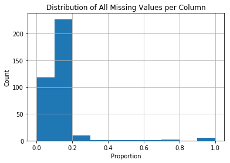

```python
# Perform an assessment of how much missing data there is in each column of the
# dataset.
missing_col = azdias.isnull().sum()/azdias.shape[0]

missing_col.hist()
plt.xlabel('Proportion')
plt.ylabel('Count')
plt.title('Distribution of All Missing Values per Column');
```

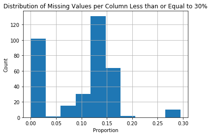

```python
# Investigate patterns in the amount of missing data in each column.
missing_col_sub = missing_col[missing_col <= 0.3]

missing_col_sub.hist()
plt.xlabel('Proportion')
plt.ylabel('Count')
plt.title('Distribution of Missing Values per Column Less than or Equal to 30%');
```

```python
# Remove the outlier columns from the dataset. (Other data engineering
# tasks such as re-encoding and imputation will be done later.)
col_outlier = missing_col[missing_col > 0.3].index
azdias_sub = azdias.drop(col_outlier, axis=1)

# Show column outliers
col_outlier
```

```
Index(['AGER_TYP', 'ALTER_HH', 'ALTER_KIND1', 'ALTER_KIND2', 'ALTER_KIND3',
       'ALTER_KIND4', 'EXTSEL992', 'GEBURTSJAHR', 'KBA05_BAUMAX',
       'KK_KUNDENTYP', 'TITEL_KZ'],
      dtype='object')
```

```python
# Remove the outlier attributes from `feat_info`
feat_info_new = feat_info[feat_info.index.isin(col_outlier) == False]
feat_info_new.shape
```

```
(355, 3)
```

##### Discussion 1.1.2: Assess Missing Data in Each Column

The distribution of the amount of missing data is skewed to the right. Most of the columns have less than or equal to 30% missing data. For the columns less than or equal to 30%, there are two distinct patterns. The first pattern is an almost single bar for no missing values. The second pattern has a slightly normal distribution for missing values less than 30% but not equal to 0. Columns which are related have missing values with almost similar proportions.

The columns with missing values greater than 30% are:

1. `AGER_TYP` - Best-ager typology
2. `ALTER_HH` - Main age within the household
3. `ALTER_KIND1` - No information
4. `ALTER_KIND2` - No information
5. `ALTER_KIND3` - No information
6. `ALTER_KIND4` - No information
7. `EXTSEL992` - No information
8. `GEBURTSJAHR` - Year of birth
9. `TITEL_KZ` - Academic title flag
10. `KK_KUNDENTYP` - Consumer pattern over past 12 months
11. `KBA05_BAUMAX` - Most common building within the microcell

#### Step 1.2: Select and Re-Encode Features

Checking for missing data isn't the only way to prepare a dataset for analysis. Since the unsupervised learning techniques to be used will only work on data that is encoded numerically, a few encoding changes or additional assumptions will be made. In addition, while almost all of the values in the dataset are encoded using numbers, not all of them represent numeric values. The third column of the feature summary (feat_info) will be checked for a summary of types of measurement.

- As mentioned earlier, there are some column types which are unknown. They must be identified first before starting the other steps.
- For numeric and interval data, these features can be kept without changes.
- Most of the variables in the dataset are ordinal in nature. While ordinal values may technically be non-linear in spacing, make the simplifying assumption that the ordinal variables can be treated as being interval in nature (that is, kept without any changes).
- Special handling may be necessary for the remaining two variable types: categorical, and 'mixed'.

In the first part of this sub-step, the columns which have unknown types will be examined and assumptions will be made. Next, an investigation of the categorical and mixed-type features will be investigated and decider whether they will be kept, dropped, or re-encoded. Finally, in the last part, a new data frame will be created with only the selected and engineered columns.

```python
# How many features are there of each data type?
print("There are {} columns which have missing data type.".format(feat_info_new['type'].isnull().sum()))
feat_info_new['type'].value_counts()
```

```
There are 50 columns which have missing data type.
```

```
ordinal        274
categorical     19
mixed            6
numeric          6
Name: type, dtype: int64
```

```python
for col in feat_info_new[feat_info_new['type'].isnull()].index:
    print(azdias_sub[col].value_counts())
```

[output not shown]

[output cut: 575 more lines]

```
13.0    27554
2.0     19917
Name: VK_DISTANZ, dtype: int64
10.0    97938
5.0     97777
6.0     88581
7.0     88552
4.0     86600
8.0     83994
9.0     82134
3.0     69634
2.0     59916
1.0     52009
11.0     8169
Name: VK_ZG11, dtype: int64
```

```python
drop_feat = ['LNR', 'EINGEFUEGT_AM', 'VERDICHTUNGSRAUM']

feat_numeric = ['ANZ_STATISTISCHE_HAUSHALTE']

feat_ordinal = ['AKT_DAT_KL',
                'ANZ_KINDER',
                'CJT_KATALOGNUTZER',
                'CJT_TYP_1',
                'CJT_TYP_2',
                'CJT_TYP_3',
                'CJT_TYP_4',
                'CJT_TYP_5',
                'CJT_TYP_6',
                'D19_KONSUMTYP_MAX',
                'D19_SOZIALES',
                'D19_TELKO_ONLINE_QUOTE_12',
                'D19_VERSI_DATUM',
                'D19_VERSI_OFFLINE_DATUM',
                'D19_VERSI_ONLINE_DATUM',
                'D19_VERSI_ONLINE_QUOTE_12',
                'DSL_FLAG',
                'FIRMENDICHTE',
                'HH_DELTA_FLAG',
                'KBA13_ANTG1',
                'KBA13_ANTG2',
                'KBA13_ANTG3',
                'KBA13_ANTG4',
                'KBA13_BAUMAX',
                'KBA13_GBZ',
                'KBA13_HHZ',
                'KBA13_KMH_210',
                'KOMBIALTER',
                'KONSUMZELLE',
                'MOBI_RASTER',
                'RT_KEIN_ANREIZ',
                'RT_SCHNAEPPCHEN',
                'RT_UEBERGROESSE',
                'UMFELD_ALT',
                'UMFELD_JUNG',
                'UNGLEICHENN_FLAG',
                'VHA',
                'VHN',
                'VK_DHT4A',
                'VK_DISTANZ',
                'VK_ZG11']

feat_categorical = ['ALTERSKATEGORIE_FEIN',
                    'D19_LETZTER_KAUF_BRANCHE',
                    'EINGEZOGENAM_HH_JAHR',
                    'GEMEINDETYP',
                    'STRUKTURTYP']
```

There are three columns which will be dropped. These are also not in the `DIAS Attributes - Values 2017 Updated.xls` file so the straightforward solution is to drop them.

1. `LNR` - This is unique for each row so it is not useful for machine learning.
2. `EINGEFUEGT_AM` - This can be categorical but there are many levels which may not be captured accurately.
3. `VERDICHTUNGSRAUM` - This can also be categorical but there are many levels too.

```python
# Drop the three features
azdias_sub = azdias_sub.drop(drop_feat, axis=1)
feat_info_new = feat_info_new.drop(drop_feat, axis=0)
azdias_sub.shape[1], feat_info_new.shape[0] # should be the same
```

```
(352, 352)
```

```python
# Fill the missing feature types
feat_info_new.loc[feat_numeric , 'type'] = 'numeric'
feat_info_new.loc[feat_ordinal, 'type'] = 'ordinal'
feat_info_new.loc[feat_categorical, 'type'] = 'categorical'
```

```python
# How many features are there of each data type?
print("There are {} columns which have missing data type.".format(feat_info_new['type'].isnull().sum()))
feat_info_new['type'].value_counts()
```

```
There are 0 columns which have missing data type.
```

```
ordinal        315
categorical     24
numeric          7
mixed            6
Name: type, dtype: int64
```

##### Step 1.2.1: Re-Encode Categorical Features

For categorical data, levels will be encoded as dummy variables. Depending on the number of categories, one of the following will be performed

- For binary (two-level) categoricals that take numeric values, they will be kept without needing to do anything.
- There is one binary variable that takes on non-numeric values. For this one, the values will be re-encoded as numbers.
- For multi-level categoricals (three or more values), the values will be encoded using multiple dummy variables.

```python
# Assess categorical variables: which are binary, which are multi-level, and
# which one needs to be re-encoded?
categorical = feat_info_new[feat_info_new['type'] == 'categorical']
```

```python
# Check categorical variable whether it is binary or multi-level
binary = []
multi_level = []
for att in categorical.index:
    if len(azdias_sub[att].value_counts()) == 2:
        binary.append(att)
    else:
        multi_level.append(att)
```

```python
binary
```

```
['ANREDE_KZ', 'GREEN_AVANTGARDE', 'SOHO_KZ', 'VERS_TYP', 'OST_WEST_KZ']
```

```python
multi_level
```

```
['CJT_GESAMTTYP',
 'FINANZTYP',
 'GFK_URLAUBERTYP',
 'LP_FAMILIE_FEIN',
 'LP_FAMILIE_GROB',
 'LP_STATUS_FEIN',
 'LP_STATUS_GROB',
 'NATIONALITAET_KZ',
 'SHOPPER_TYP',
 'ZABEOTYP',
 'GEBAEUDETYP',
 'CAMEO_DEUG_2015',
 'CAMEO_DEU_2015',
 'D19_KONSUMTYP',
 'ALTERSKATEGORIE_FEIN',
 'D19_LETZTER_KAUF_BRANCHE',
 'EINGEZOGENAM_HH_JAHR',
 'GEMEINDETYP',
 'STRUKTURTYP']
```

```python
# Re-encode the values as numbers for `OST_WEST_KZ`
azdias_sub['OST_WEST_KZ'] = azdias_sub['OST_WEST_KZ'].replace({'O':1.0, 'W':2.0})
```

```python
azdias_sub['OST_WEST_KZ'].value_counts()
```

```
2.0    629528
1.0    168545
Name: OST_WEST_KZ, dtype: int64
```

```python
# Re-encode categorical variable(s) to be kept in the analysis.
azdias_enc = pd.get_dummies(azdias_sub, columns=multi_level)
```

##### Step 1.2.2: Engineer Mixed-Type Features

There are a handful of features that are marked as "mixed" in the feature summary that require special treatment in order to be included in the analysis.

- `PRAEGENDE_JUGENDJAHRE` - combines information on three dimensions: generation by decade, movement (mainstream vs. avantgarde), and nation (east vs. west). While there aren't enough levels to disentangle east from west, two new variables will be created to capture the other two dimensions: an interval-type variable for decade, and a binary variable for movement.
- `CAMEO_INTL_2015` - combines information on two axes: wealth and life stage. The two-digit codes will be broken by their 'tens'-place and 'ones'-place digits into two new ordinal variables (which, for the purposes of this project, is equivalent to just treating them as their raw numeric values).

```python
# Investigate "PRAEGENDE_JUGENDJAHRE" and engineer two new variables.
# Engineer new column `DECADE`
azdias_enc['DECADE'] = azdias_enc['PRAEGENDE_JUGENDJAHRE']

# Engineer new column `MOVEMENT`
mainstream = [1.0, 3.0, 5.0, 8.0, 10.0, 12.0, 14.0]
avantgarde = [2.0, 4.0, 6.0, 7.0, 9.0, 11.0, 13.0, 15.0]

main = azdias_enc['PRAEGENDE_JUGENDJAHRE'].isin(mainstream)
azdias_enc.loc[main, 'MOVEMENT'] = 1.0
avant = azdias_enc['PRAEGENDE_JUGENDJAHRE'].isin(avantgarde)
azdias_enc.loc[avant, 'MOVEMENT'] = 2.0
```

```python
azdias_enc['MOVEMENT'].value_counts()
```

```
1.0    607832
2.0    175225
Name: MOVEMENT, dtype: int64
```

```python
# Investigate "CAMEO_INTL_2015" and engineer two new variables.
# Engineer new column 'WEALTH'
azdias_enc['WEALTH'] = azdias_enc['CAMEO_INTL_2015'] // 10

# Engineer new column 'LIFE_STAGE'
azdias_enc['LIFE_STAGE'] = azdias_enc['CAMEO_INTL_2015'] % 10
```

```python
# Check other categories
mixed = feat_info_new[feat_info_new['type'] == 'mixed']
mixed
```

| attribute | information_level | type | missing_or_unknown |
| --- | --- | --- | --- |
| LP_LEBENSPHASE_FEIN | person | mixed | [0] |
| LP_LEBENSPHASE_GROB | person | mixed | [0] |
| PRAEGENDE_JUGENDJAHRE | person | mixed | [-1, 0] |
| WOHNLAGE | building | mixed | [-1] |
| CAMEO_INTL_2015 | microcell_rr4 | mixed | [-1, XX] |
| PLZ8_BAUMAX | macrocell_plz8 | mixed | [-1, 0] |

```python
# Re-encode `LP_LEBENSPHASE_GROB` and `WOHNLAGE` to be kept in the analysis.
azdias_engg = pd.get_dummies(azdias_enc, columns=['LP_LEBENSPHASE_GROB', 'WOHNLAGE'])
```

##### Discussion 1.2.2: Engineer Mixed-Type Features

There were multiple ways to deal with the mixed-type features. The details are described below:

1. `LP_LEBENSPHASE_FEIN` - This was dropped because it had too many levels which might not be captured accurately.
2. `LP_LEBENSPHASE_GROB` - This can be treated as categorical so it was re-encoded using one-hot-encoding.
3. `PRAEGENDE_JUGENDJAHRE` - This was engineered using the procedures outlined above.
4. `WOHNLAGE` - This can be treated as categorical so it was re-encoded using one-hot-encoding.
5. `CAMEO_INTL_2015` - This was engineered using the procedures outlined above.
6. `PLZ8_BAUMAX` - This can be treated as interval so nothing was done.

##### Step 1.2.3: Complete Feature Selection

In order to finish this step up, the dataframe should consist of the following:

- All numeric, interval, and ordinal type columns from the original dataset.
- Binary categorical features (all numerically-encoded).
- Engineered features from other multi-level categorical features and mixed features.

```python
# Do whatever you need to in order to ensure that the dataframe only contains
# the columns that should be passed to the algorithm functions.
azdias_clean = azdias_engg.drop(['PRAEGENDE_JUGENDJAHRE', 'CAMEO_INTL_2015', 'LP_LEBENSPHASE_FEIN'], axis=1)
```

```python
azdias_clean.info()
```

```
<class 'pandas.core.frame.DataFrame'>
RangeIndex: 891221 entries, 0 to 891220
Columns: 595 entries, AKT_DAT_KL to WOHNLAGE_8.0
dtypes: float64(332), uint8(263)
memory usage: 2.4 GB
```

#### Step 1.3: Create Cleaning Function

```python
def clean_data(df):
    """
    Perform feature trimming, re-encoding, and engineering for demographics
    data

    INPUT: Demographics DataFrame
    OUTPUT: Trimmed and cleaned demographics DataFrame
    """

    # Put in code here to execute all main cleaning steps:
    # convert missing value codes into NaNs, ...
    for column in df:
        if column == 'RESPONSE':
            pass
        else:
            mask = df[column].isin(feat_info.loc[column, 'missing_or_unknown'])
            df.loc[mask, column] = np.NaN

    # remove selected columns and rows, ...
    col_outlier = ['AGER_TYP',
                   'ALTER_HH',
                   'ALTER_KIND1',
                   'ALTER_KIND2',
                   'ALTER_KIND3',
                   'ALTER_KIND4',
                   'EXTSEL992',
                   'GEBURTSJAHR',
                   'TITEL_KZ',
                   'KK_KUNDENTYP',
                   'KBA05_BAUMAX']
    df_sub = df.drop(col_outlier, axis=1)

    # drop additional columns
    df_sub = df_sub.drop(['LNR', 'EINGEFUEGT_AM', 'VERDICHTUNGSRAUM'], axis=1)

    # select, re-encode, and engineer column values.
    df_sub['OST_WEST_KZ'] = df_sub['OST_WEST_KZ'].replace({'O':1.0, 'W':2.0})

    # change to float for the other three datasets
    df_sub['CAMEO_DEUG_2015'] = df_sub['CAMEO_DEUG_2015'].astype('float')

    categorical = ['CJT_GESAMTTYP',
                   'FINANZTYP',
                   'GFK_URLAUBERTYP',
                   'LP_FAMILIE_FEIN',
                   'LP_FAMILIE_GROB',
                   'LP_STATUS_FEIN',
                   'LP_STATUS_GROB',
                   'NATIONALITAET_KZ',
                   'SHOPPER_TYP',
                   'ZABEOTYP',
                   'GEBAEUDETYP',
                   'CAMEO_DEUG_2015',
                   'CAMEO_DEU_2015',
                   'D19_KONSUMTYP',
                   'ALTERSKATEGORIE_FEIN',
                   'D19_LETZTER_KAUF_BRANCHE',
                   'EINGEZOGENAM_HH_JAHR',
                   'GEMEINDETYP',
                   'STRUKTURTYP',
                   'LP_LEBENSPHASE_GROB',
                   'WOHNLAGE']

    df_enc = pd.get_dummies(df_sub, columns=categorical)

    # Engineer mixed-type features
    df_enc['DECADE'] = df_enc['PRAEGENDE_JUGENDJAHRE']
    main = df_enc['PRAEGENDE_JUGENDJAHRE'].isin([1.0, 3.0, 5.0, 8.0, 10.0, 12.0, 14.0])
    df_enc.loc[main, 'MOVEMENT'] = 1.0
    avant = df_enc['PRAEGENDE_JUGENDJAHRE'].isin([2.0, 4.0, 6.0, 7.0, 9.0, 11.0, 13.0, 15.0])
    df_enc.loc[avant, 'MOVEMENT'] = 2.0

    if df_enc['CAMEO_INTL_2015'].dtype == 'float64':
        df_enc['WEALTH'] = df_enc['CAMEO_INTL_2015'] // 10
        df_enc['LIFE_STAGE'] = df_enc['CAMEO_INTL_2015'] % 10
    else:
        df_enc['WEALTH'] = df_enc['CAMEO_INTL_2015'].str[0].astype('float')
        df_enc['LIFE_STAGE'] = df_enc['CAMEO_INTL_2015'].str[1].astype('float')

    df_clean = df_enc.drop(['PRAEGENDE_JUGENDJAHRE', 'CAMEO_INTL_2015', 'LP_LEBENSPHASE_FEIN'], axis=1)

    # Return the cleaned dataframe.
    return df_clean
```

```python
azdias_clone = clean_data(azdias)
```

```python
# Should be True
azdias_clone.shape == azdias_clean.shape
```

```
True
```

### Step 2: Feature Transformation

#### Step 2.1: Apply Feature Scaling

Before dimensionality reduction techniques are applied to the data, feature scaling must be performed so that the principal component vectors are not influenced by the natural differences in scale for features.

- `sklearn` requires that data not have missing values in order for its estimators to work properly. So, before applying the scaler to the data, the DataFrame must be cleaned of the remaining missing values before applying the scaler. This was done by applying an Imputer to replace all missing values.
- For the actual scaling function, a StandardScaler instance was done, scaling each feature to mean 0 and standard deviation 1.
- For these classes, the .fit_transform() method was used to both fit a procedure to the data as well as apply the transformation to the data at the same time.

```python
# If you've not yet cleaned the dataset of all NaN values, then investigate and
# do that now.
azdias_null = azdias_clean[azdias_clean.isnull().any(axis=1)] # subset of missing data

# Compare shape between `azdias_clean` and its subset of missing data
(azdias_clean.shape, azdias_null.shape)
```

```
((891221, 595), (404662, 595))
```

```python
# Apply `Imputer` to replace all missing values with the mean
imputer = Imputer()
azdias_impute = imputer.fit_transform(azdias_clean)
```

```python
# Apply feature scaling to the general population demographics data.
scaler = StandardScaler()
azdias_scaled = scaler.fit_transform(azdias_impute)
```

#### Discussion 2.1: Apply Feature Scaling

Feature scaling was then applied using StandardScaler instance from sklearn and the .fit_transform() method to fit the procedure to the data and apply the transformation at the same time. The instance returned an array for use in the next step which is PCA.

#### Step 2.2: Perform Dimensionality Reduction

On the scaled data, dimensionality reduction techniques can now be applied.

- `sklearn`'s PCA class will be used to apply principal component analysis on the data, thus finding the vectors of maximal variance in the data. To start, at least half the number of features will be set (so there's enough features to see the general trend in variability).
- The ratio of variance explained by each principal component as well as the cumulative variance explained will be checked by plotting the cumulative or sequential values using matplotlib's plot() function. Based on the findings, a value for the number of transformed features will be retained for the clustering part of the project.
- Once a choice for the number of components to keep has been made, the PCA instance will be re-fit to perform the decided-on transformation.

```python
# Apply PCA to the data.
n_components = int(azdias_impute.shape[1] / 2) # Half the number of features

pca = PCA(n_components)
azdias_pca = pca.fit_transform(azdias_scaled)
```

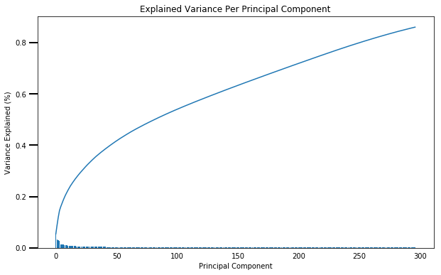

```python
# Investigate the variance accounted for by each principal component.
ind = np.arange(n_components)
vals = pca.explained_variance_ratio_

plt.figure(figsize=(10, 6))
ax = plt.subplot()
cumvals = np.cumsum(vals)
ax.bar(ind, vals)
ax.plot(ind, cumvals)
for i in range(n_components):
    ax.xaxis.set_tick_params(width=0)
    ax.yaxis.set_tick_params(width=2, length=12)

    ax.set_xlabel("Principal Component")
    ax.set_ylabel("Variance Explained (%)")
    plt.title('Explained Variance Per Principal Component')
```

```python
# Re-apply PCA to the data while selecting for number of components to retain.
sum(pca.explained_variance_ratio_)
```

```
0.8600423258190365
```

#### Discussion 2.2: Perform Dimensionality Reduction

As suggested by the procedure, half of the number of features (297 out of 595) was used as the initial number of components for the principal component analysis of the data. As expected, the amount of original variability in the original data decreased per subsequent component. The 297 components can explain at least 86% of the variability in the original dataset. This is good enough for further analysis and no further re-application is necesssary.

#### Step 2.3: Interpret Principal Components

Now that the principal components have been transformed, the weight of each variable on the first few components should be checked to see if they can be interpreted in some fashion.

Each principal component is a unit vector that points in the direction of highest variance (after accounting for the variance captured by earlier principal components). The further a weight is from zero, the more the principal component is in the direction of the corresponding feature. If two features have large weights of the same sign (both positive or both negative), then increases in one tend expect to be associated with increases in the other. To contrast, features with different signs can be expected to show a negative correlation: increases in one variable should result in a decrease in the other.

To investigate the features, each weight should be mapped to their corresponding feature name, then the features should be sorted according to weight. The most interesting features for each principal component, then, will be those at the beginning and end of the sorted list.

```python
# Map weights for the first principal component to corresponding feature names
# and then print the linked values, sorted by weight.

# Dimension indexing
dimensions = dimensions = ['Dimension {}'.format(i) for i in range(1,len(pca.components_)+1)]

# PCA components
components = pd.DataFrame(np.round(pca.components_, 4), columns = azdias_clean.keys())
components.index = dimensions
```

```python
components.head(3)
```

|  | AKT_DAT_KL | ANZ_HAUSHALTE_AKTIV | ANZ_HH_TITEL | ANZ_KINDER | ANZ_PERSONEN | ANZ_STATISTISCHE_HAUSHALTE | ANZ_TITEL | ARBEIT | BALLRAUM | CJT_KATALOGNUTZER | ... | LP_LEBENSPHASE_GROB_11.0 | LP_LEBENSPHASE_GROB_12.0 | WOHNLAGE_0.0 | WOHNLAGE_1.0 | WOHNLAGE_2.0 | WOHNLAGE_3.0 | WOHNLAGE_4.0 | WOHNLAGE_5.0 | WOHNLAGE_7.0 | WOHNLAGE_8.0 |
| --- | --- | --- | --- | --- | --- | --- | --- | --- | --- | --- | --- | --- | --- | --- | --- | --- | --- | --- | --- | --- | --- |
| Dimension 1 | -0.0656 | -0.0730 | -0.0172 | 0.0343 | 0.0771 | -0.0719 | 0.0027 | -0.0816 | 0.0602 | -0.0387 | ... | 0.0387 | 0.0615 | 0.0105 | 0.0165 | 0.0095 | -0.0192 | -0.0433 | -0.0350 | 0.0697 | 0.0265 |
| Dimension 2 | -0.0061 | 0.0125 | -0.0069 | 0.0698 | 0.0647 | 0.0103 | -0.0054 | 0.0311 | -0.0166 | -0.1172 | ... | 0.0372 | -0.0111 | 0.0105 | -0.0165 | -0.0060 | 0.0108 | 0.0230 | 0.0222 | -0.0169 | 0.0073 |
| Dimension 3 | 0.0053 | 0.0199 | 0.0251 | 0.0095 | 0.0056 | 0.0185 | 0.0115 | -0.0288 | -0.0912 | -0.0293 | ... | 0.0052 | -0.0054 | 0.0015 | 0.0546 | 0.0330 | 0.0176 | 0.0082 | -0.0035 | -0.0709 | -0.0213 |

3 rows × 595 columns

```python
# Map weights for the first principal component to corresponding feature names
# and then print the linked values, sorted by weight.
components.iloc[0].sort_values(ascending=False)
```

```
MOBI_REGIO                  0.1307
PLZ8_ANTG1                  0.1247
KBA13_ANTG1                 0.1244
KBA05_ANTG1                 0.1211
MOBI_RASTER                 0.1206
KBA05_AUTOQUOT              0.1155
KBA05_GBZ                   0.1148
KBA13_AUTOQUOTE             0.1134
FINANZ_MINIMALIST           0.1008
D19_GESAMT_ANZ_24           0.0934
KBA13_GBZ                   0.0924
PLZ8_GBZ                    0.0913
KBA05_ANHANG                0.0899
KONSUMNAEHE                 0.0898
KBA13_ALTERHALTER_60        0.0897
D19_VERSAND_ANZ_24          0.0872
D19_GESAMT_ANZ_12           0.0871
ONLINE_AFFINITAET           0.0858
KBA13_HALTER_55             0.0853
INNENSTADT                  0.0846
KBA13_HALTER_50             0.0804
D19_VERSAND_ANZ_12          0.0802
KBA05_KRSAQUOT              0.0780
ANZ_PERSONEN                0.0771
FIRMENDICHTE                0.0761
KBA13_KRSAQUOT              0.0732
ZABEOTYP_1.0                0.0700
WOHNLAGE_7.0                0.0697
D19_KONSUMTYP_1.0           0.0688
KBA13_SEG_GELAENDEWAGEN     0.0683
                             ...
RELAT_AB                   -0.0725
KBA05_ANTG3                -0.0727
CAMEO_DEUG_2015_9.0        -0.0727
ANZ_HAUSHALTE_AKTIV        -0.0730
KBA13_HALTER_35            -0.0745
KBA13_HALTER_30            -0.0776
KBA05_ANTG4                -0.0798
ARBEIT                     -0.0816
LP_STATUS_FEIN_1.0         -0.0818
VK_ZG11                    -0.0829
D19_VERSAND_ONLINE_DATUM   -0.0846
PLZ8_ANTG2                 -0.0852
D19_GESAMT_ONLINE_DATUM    -0.0873
D19_VERSAND_DATUM          -0.0906
D19_KONSUMTYP_MAX          -0.0912
D19_GESAMT_DATUM           -0.0939
VK_DISTANZ                 -0.0951
VK_DHT4A                   -0.0954
FINANZ_HAUSBAUER           -0.0972
HH_EINKOMMEN_SCORE         -0.1020
ORTSGR_KLS9                -0.1029
EWDICHTE                   -0.1035
LP_STATUS_GROB_1.0         -0.1118
PLZ8_BAUMAX                -0.1177
PLZ8_ANTG4                 -0.1193
WEALTH                     -0.1196
KBA13_BAUMAX               -0.1197
KBA13_ANTG4                -0.1206
KBA13_ANTG3                -0.1238
PLZ8_ANTG3                 -0.1241
Name: Dimension 1, Length: 595, dtype: float64
```

```python
# Map weights for the second principal component to corresponding feature names
# and then print the linked values, sorted by weight.
components.iloc[1].sort_values(ascending=False)
```

```
ONLINE_AFFINITAET                         0.1490
DECADE                                    0.1474
D19_GESAMT_ANZ_24                         0.1375
D19_GESAMT_ANZ_12                         0.1299
FINANZ_SPARER                             0.1284
CJT_TYP_2                                 0.1264
D19_VERSAND_ANZ_24                        0.1256
CJT_TYP_1                                 0.1254
D19_VERSAND_ANZ_12                        0.1161
SEMIO_TRADV                               0.1093
D19_GESAMT_ONLINE_QUOTE_12                0.1070
D19_VERSAND_ONLINE_QUOTE_12               0.1038
SEMIO_PFLICHT                             0.1038
D19_KONSUMTYP_1.0                         0.1027
SEMIO_RAT                                 0.0982
FINANZ_ANLEGER                            0.0956
ZABEOTYP_4.0                              0.0924
D19_VERSAND_REST                          0.0886
FINANZTYP_1.0                             0.0882
RT_KEIN_ANREIZ                            0.0858
D19_BANKEN_ANZ_24                         0.0833
D19_BANKEN_DIREKT                         0.0815
D19_TELKO_MOBILE                          0.0792
SEMIO_REL                                 0.0776
FINANZ_UNAUFFAELLIGER                     0.0772
SEMIO_KULT                                0.0756
RT_UEBERGROESSE                           0.0751
D19_SCHUHE                                0.0747
D19_DROGERIEARTIKEL                       0.0746
LP_STATUS_FEIN_2.0                        0.0740
                                           ...
LP_LEBENSPHASE_GROB_2.0                  -0.0652
SEMIO_ERL                                -0.0671
D19_LETZTER_KAUF_BRANCHE_D19_UNBEKANNT   -0.0671
D19_GESAMT_OFFLINE_DATUM                 -0.0703
FINANZTYP_2.0                            -0.0721
VK_DISTANZ                               -0.0733
D19_VERSI_DATUM                          -0.0757
CJT_GESAMTTYP_2.0                        -0.0781
D19_TELKO_DATUM                          -0.0860
RETOURTYP_BK_S                           -0.0887
D19_BANKEN_ONLINE_DATUM                  -0.0909
FINANZ_MINIMALIST                        -0.0920
SEMIO_LUST                               -0.0928
KOMBIALTER                               -0.0930
D19_BANKEN_DATUM                         -0.0987
D19_KONSUMTYP_MAX                        -0.1005
W_KEIT_KIND_HH                           -0.1009
VK_DHT4A                                 -0.1131
ALTERSKATEGORIE_GROB                     -0.1171
CJT_KATALOGNUTZER                        -0.1172
ZABEOTYP_3.0                             -0.1203
D19_VERSAND_DATUM                        -0.1249
D19_GESAMT_DATUM                         -0.1262
FINANZ_VORSORGER                         -0.1281
CJT_TYP_3                                -0.1285
D19_VERSAND_ONLINE_DATUM                 -0.1291
CJT_TYP_6                                -0.1302
CJT_TYP_5                                -0.1335
D19_GESAMT_ONLINE_DATUM                  -0.1336
CJT_TYP_4                                -0.1337
Name: Dimension 2, Length: 595, dtype: float64
```

```python
# Map weights for the third principal component to corresponding feature names
# and then print the linked values, sorted by weight.
components.iloc[2].sort_values(ascending=False)
```

```
KBA13_HERST_BMW_BENZ           0.1782
KBA13_SEG_OBEREMITTELKLASSE    0.1525
KBA13_MERCEDES                 0.1522
KBA13_BMW                      0.1487
KBA13_SITZE_4                  0.1444
KBA13_SEG_SPORTWAGEN           0.1390
KBA05_HERST1                   0.1232
KBA13_KMH_211                  0.1222
KBA13_KMH_250                  0.1200
KBA13_SEG_OBERKLASSE           0.1195
KBA13_KW_121                   0.1192
KBA05_KW3                      0.1150
KBA13_CCM_2501                 0.1133
EWDICHTE                       0.1070
KBA05_MOTOR                    0.1057
KBA13_CCM_3000                 0.1056
KBA13_KRSHERST_BMW_BENZ        0.1040
KBA05_MOD1                     0.1017
KBA05_CCM4                     0.1009
KBA13_CCM_3001                 0.1008
OST_WEST_KZ                    0.1003
KBA13_HALTER_65                0.0968
ORTSGR_KLS9                    0.0963
KBA05_SEG5                     0.0923
STRUKTURTYP_3.0                0.0865
KBA13_CCM_2500                 0.0831
MOVEMENT                       0.0809
GREEN_AVANTGARDE               0.0801
KBA05_SEG8                     0.0795
KBA05_CCM3                     0.0787
                                ...
KBA13_HALTER_60               -0.0723
INNENSTADT                    -0.0753
KBA13_FORD                    -0.0770
KBA05_MAXHERST                -0.0789
KBA13_CCM_1400                -0.0812
KBA05_CCM1                    -0.0813
KBA13_ALTERHALTER_30          -0.0819
KBA13_OPEL                    -0.0839
KBA13_KRSHERST_FORD_OPEL      -0.0847
KONSUMNAEHE                   -0.0848
KBA13_HALTER_55               -0.0854
FIRMENDICHTE                  -0.0856
KBA13_HALTER_50               -0.0860
STRUKTURTYP_1.0               -0.0866
KKK                           -0.0867
KBA05_KW1                     -0.0872
BALLRAUM                      -0.0912
KBA13_SEG_KLEINST             -0.0926
KBA13_FAB_ASIEN               -0.0946
KBA13_HERST_ASIEN             -0.0981
KBA13_ALTERHALTER_60          -0.0986
KBA13_HERST_FORD_OPEL         -0.1017
KBA13_KW_0_60                 -0.1022
KBA13_SEG_KOMPAKTKLASSE       -0.1096
KBA13_HALTER_20               -0.1130
KBA13_KMH_180                 -0.1134
KBA13_HALTER_25               -0.1172
KBA13_SEG_KLEINWAGEN          -0.1251
KBA13_KMH_140_210             -0.1255
KBA13_SITZE_5                 -0.1471
Name: Dimension 3, Length: 595, dtype: float64
```

#### Discussion 2.3: Interpret Principal Components

For each principal component or dimension, the top 3 and bottom 3 weights with their corresponding feature names will be investigated for any associations.

**Dimension 1:**

- `MOBI_REGIO` **(0.1307)** - moving patterns
- `PLZ8_ANTG1` **(0.1247)** - number of 1-2 family houses in the PLZ8
- `KBA13_ANTG1` **(0.1244)** - no information
- `KBA13_ANTG4` **(-0.1206)** - no information
- `KBA13_ANTG3` **(-0.1238)** - no information
- `PLZ8_ANTG3` **(-0.1241)** - number of 6-10 family houses in the PLZ8

**Dimension 2:**

- `ONLINE_AFFINITAET` **(0.1490)** - online affinity
- `DECADE` **(0.1474)** - decade of the dominating movement in the person's youth
- `D19_GESAMT_ANZ_24` **(0.1375)** - transaction activity TOTAL POOL in the last 24 months
- `CJT_TYP_5` **(-0.1335)** - no information
- `D19_GESAMT_ONLINE_DATUM` **(-0.1336)** - actuality of the last transaction with the complete file ONLINE
- `CJT_TYP_4` **(-0.1337)** - no information

**Interpretation:** The second principal component increases with higher online affinity, more recent decade of the dominating movement, and higher transactions in the last 24 months. Likewise, `CJT_TYP` is also not described in the attributes file but it may be related to the customer journey typology. This principal component decreases with people with older transactions which is expected because the converse is true.

**Dimension 3:**

- `KBA13_HERST_BMW_BENZ` **(0.1782)** - share of BMW & Mercedes Benz within the PLZ8
- `KBA13_SEG_OBEREMITTELKLASSE` **(0.1525)** - share of upper middle class cars and upper class cars
- `KBA13_MERCEDES` **(0.1522)** - share of MERCEDES within the PLZ8
- `KBA13_SEG_KLEINWAGEN` **(-0.1251)** - share of small and very small cars in the PLZ8
- `KBA13_KMH_140_210` **(-0.1255)** - share of cars with max speed between 140 and 210 km/h within the PLZ8
- `KBA13_SITZE_5` **(-0.1471)** - number of cars with 5 seats in the PLZ8

**Interpretation:** The third principal component is primarily affected by car ownership. People who own a lot of luxury cars such as BWM and Mercedes increase this component. On the other hand, people who own budget cars such as Ford Fiesta decrease this component.

### Step 3: Clustering

#### Step 3.1 Apply Clustering to General Population

Now, it's time to see how the data clusters in the principal components space. In this substep, k-means clustering will be applied to the dataset and the average within-cluster distances from each point to their assigned cluster's centroid will be used to decide on a number of clusters to keep.

- sklearn's KMeans class will be used to perform k-means clustering on the PCA-transformed data.
- Then, the average difference from each point to its assigned cluster's center will be computed.
- The above two steps will be performed for a 30 different cluster counts to see how the average distance decreases with an increasing number of clusters.
- Once final number of clusters to use is selected, KMeans instance will be re-fit to perform the clustering operation.

```python
# Over a number of different cluster counts...
scores = []
centers = list(range(1,31))
for center in centers:

    # run k-means clustering on the data and...
    kmeans = MiniBatchKMeans(n_clusters=center, random_state=28)
    model = kmeans.fit(azdias_pca)

    # compute the average within-cluster distances.
    score = np.abs(model.score(azdias_pca))
    scores.append(score)
```

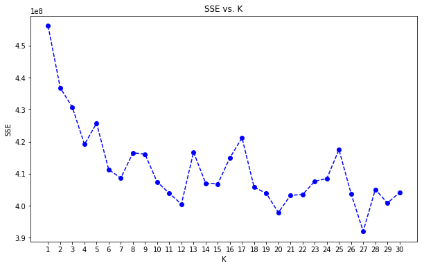

```python
# Investigate the change in within-cluster distance across number of clusters.

plt.figure(figsize=(10, 6))
ax = plt.subplot()
plt.plot(centers, scores, linestyle='--', marker='o', color='b');
plt.xlabel('K');
plt.xticks(np.arange(1, 31, step=1))
plt.ylabel('SSE');
plt.title('SSE vs. K');
```

```python
# Re-fit the k-means model with the selected number of clusters and obtain
# cluster predictions for the general population demographics data.

kmeans = KMeans(n_clusters=30, random_state=42, n_jobs=-1)
azdias_preds = kmeans.fit_predict(azdias_pca)
```

```python
azdias_cluster = pd.DataFrame(np.round(azdias_pca, 4), columns = dimensions)
azdias_cluster.insert(loc=0, column='Cluster', value=azdias_preds)
azdias_cluster.head()
```

|  | Cluster | Dimension 1 | Dimension 2 | Dimension 3 | Dimension 4 | Dimension 5 | Dimension 6 | Dimension 7 | Dimension 8 | Dimension 9 | ... | Dimension 288 | Dimension 289 | Dimension 290 | Dimension 291 | Dimension 292 | Dimension 293 | Dimension 294 | Dimension 295 | Dimension 296 | Dimension 297 |
| --- | --- | --- | --- | --- | --- | --- | --- | --- | --- | --- | --- | --- | --- | --- | --- | --- | --- | --- | --- | --- | --- |
| 0 | 2 | -2.0038 | -3.7460 | -0.6051 | -1.2946 | 0.9113 | -2.9634 | -0.4355 | -2.8837 | -2.6265 | ... | -0.0147 | -0.0557 | -0.2604 | -0.4926 | 0.1466 | 0.0178 | -0.1896 | 0.1651 | -0.1509 | -0.1555 |
| 1 | 20 | -4.9476 | 2.8151 | 5.6880 | -6.3455 | -0.5982 | 0.3527 | -4.9638 | -0.2976 | 3.1640 | ... | -0.4777 | 0.7157 | -0.2551 | -0.4078 | -0.6233 | 0.2595 | -1.1972 | 1.0595 | 0.2841 | -0.3378 |
| 2 | 20 | 0.2394 | -1.8732 | 2.6850 | -3.8009 | 4.5369 | -1.2006 | 2.3207 | 7.2932 | 1.7762 | ... | 0.9480 | 0.6101 | 1.4530 | -1.3604 | -2.1939 | 1.1322 | 1.1789 | -0.8759 | 1.0871 | 0.2586 |
| 3 | 25 | 4.9171 | -6.1492 | -1.1048 | -2.4380 | -1.9617 | 1.2599 | -2.6961 | 1.1186 | -0.2411 | ... | -0.0287 | -1.1953 | -0.8086 | -0.0246 | 0.8108 | 0.0747 | -0.6329 | -0.1099 | 0.3132 | -1.3517 |
| 4 | 1 | 5.6603 | 8.4982 | 4.4998 | 7.2875 | -2.8461 | -0.1177 | 2.1791 | 1.4116 | -4.6492 | ... | -2.0260 | 0.9842 | -0.1121 | -1.5900 | -1.7233 | -0.2615 | 1.5584 | -0.4347 | 1.4553 | -0.3180 |

5 rows × 298 columns

#### Discussion 3.1 Apply Clustering to General Population

Instead of using KMeans class to perform k-means clustering on the PCA-transformed data for a number of different cluster counts, an alternative called MiniBatchKMeans was used instead. The user guide says that it uses mini-batches to reduce the computation time, while still attempting to optimise the same objective function. MiniBatchKMeans converges faster than KMeans, but the quality of the results is reduced. In practice this difference in quality can be quite small. The algorithm did not resolve after one hour for KMeans, hence the variant MiniBatchKMeans was used to provide a significantly faster solution.

The scree plot shows that the score or the sum of the squared errors (SSE) generally decreased as the number of clusters increased. As the instruction suggested, the maximum clusters used was 30. The 'elbow method' is not applicable in the plot because there is no visible leveling observed. Even though 30 clusters did not produce the lowest SSE, it was still used as the number of clusters for the full KMeans clustering operation.

#### Step 3.2 Apply All Steps to the Customer Data

Now that the clusters and cluster centers for the general population have been obtained, it's time to see how the customer data maps on to those clusters. The fits from the general population will be used to clean, transform, and cluster the customer data. In the last step, there will be an interperation on how the general population fits apply to the customer data.

```python
# This is to set the object type since these two columns are mixed type
dtypes = {"CAMEO_DEUG_2015": object, "CAMEO_INTL_2015": object}
```

```python
# Load in the customer demographics data.
customers = pd.read_csv('data/customers.csv', dtype=dtypes)
```

```python
customers_sub = customers.drop(['CUSTOMER_GROUP', 'ONLINE_PURCHASE', 'PRODUCT_GROUP'], axis=1)
print(customers_sub.shape)
customers_sub.head()
```

```
(191652, 366)
```

|  | LNR | AGER_TYP | AKT_DAT_KL | ALTER_HH | ALTER_KIND1 | ALTER_KIND2 | ALTER_KIND3 | ALTER_KIND4 | ALTERSKATEGORIE_FEIN | ANZ_HAUSHALTE_AKTIV | ... | VHN | VK_DHT4A | VK_DISTANZ | VK_ZG11 | W_KEIT_KIND_HH | WOHNDAUER_2008 | WOHNLAGE | ZABEOTYP | ANREDE_KZ | ALTERSKATEGORIE_GROB |
| --- | --- | --- | --- | --- | --- | --- | --- | --- | --- | --- | --- | --- | --- | --- | --- | --- | --- | --- | --- | --- | --- |
| 0 | 9626 | 2 | 1.0 | 10.0 | NaN | NaN | NaN | NaN | 10.0 | 1.0 | ... | 3.0 | 5.0 | 3.0 | 2.0 | 6.0 | 9.0 | 7.0 | 3 | 1 | 4 |
| 1 | 9628 | -1 | 9.0 | 11.0 | NaN | NaN | NaN | NaN | NaN | NaN | ... | NaN | 6.0 | 6.0 | 3.0 | 0.0 | 9.0 | NaN | 3 | 1 | 4 |
| 2 | 143872 | -1 | 1.0 | 6.0 | NaN | NaN | NaN | NaN | 0.0 | 1.0 | ... | 4.0 | 10.0 | 13.0 | 11.0 | 6.0 | 9.0 | 2.0 | 3 | 2 | 4 |
| 3 | 143873 | 1 | 1.0 | 8.0 | NaN | NaN | NaN | NaN | 8.0 | 0.0 | ... | 2.0 | 6.0 | 4.0 | 2.0 | NaN | 9.0 | 7.0 | 1 | 1 | 4 |
| 4 | 143874 | -1 | 1.0 | 20.0 | NaN | NaN | NaN | NaN | 14.0 | 7.0 | ... | 4.0 | 3.0 | 5.0 | 4.0 | 2.0 | 9.0 | 3.0 | 1 | 1 | 3 |

5 rows × 366 columns

```python
# Apply preprocessing onto the customer data
customers_clean = clean_data(customers_sub)
```

```python
# Check for missing column in `customers_clean`
missing = list(np.setdiff1d(azdias_clean.columns, customers_clean.columns))
missing
```

```
['ALTERSKATEGORIE_FEIN_1.0',
 'EINGEZOGENAM_HH_JAHR_1900.0',
 'EINGEZOGENAM_HH_JAHR_1904.0',
 'EINGEZOGENAM_HH_JAHR_1971.0',
 'EINGEZOGENAM_HH_JAHR_1984.0',
 'GEBAEUDETYP_5.0']
```

```python
# Add the missing column with default value of 0
for m in missing:
    customers_clean[m] = 0
    customers_clean[m] = customers_clean[m].astype('uint8')

print(customers_clean.shape)
customers_clean.head()
```

```
(191652, 595)
```

|  | AKT_DAT_KL | ANZ_HAUSHALTE_AKTIV | ANZ_HH_TITEL | ANZ_KINDER | ANZ_PERSONEN | ANZ_STATISTISCHE_HAUSHALTE | ANZ_TITEL | ARBEIT | BALLRAUM | CJT_KATALOGNUTZER | ... | DECADE | MOVEMENT | WEALTH | LIFE_STAGE | ALTERSKATEGORIE_FEIN_1.0 | EINGEZOGENAM_HH_JAHR_1900.0 | EINGEZOGENAM_HH_JAHR_1904.0 | EINGEZOGENAM_HH_JAHR_1971.0 | EINGEZOGENAM_HH_JAHR_1984.0 | GEBAEUDETYP_5.0 |
| --- | --- | --- | --- | --- | --- | --- | --- | --- | --- | --- | --- | --- | --- | --- | --- | --- | --- | --- | --- | --- | --- |
| 0 | 1.0 | 1.0 | 0.0 | 0.0 | 2.0 | 1.0 | 0.0 | 1.0 | 3.0 | 4.0 | ... | 4.0 | 2.0 | 1.0 | 3.0 | 0 | 0 | 0 | 0 | 0 | 0 |
| 1 | 9.0 | NaN | NaN | 0.0 | 3.0 | NaN | 0.0 | NaN | NaN | NaN | ... | NaN | NaN | NaN | NaN | 0 | 0 | 0 | 0 | 0 | 0 |
| 2 | 1.0 | 1.0 | 0.0 | 0.0 | 1.0 | 1.0 | 0.0 | 3.0 | 7.0 | 5.0 | ... | 4.0 | 2.0 | 3.0 | 4.0 | 0 | 0 | 0 | 0 | 0 | 0 |
| 3 | 1.0 | NaN | NaN | 0.0 | 0.0 | 1.0 | 0.0 | 1.0 | 7.0 | 5.0 | ... | 1.0 | 1.0 | 2.0 | 4.0 | 0 | 0 | 0 | 0 | 0 | 0 |
| 4 | 1.0 | 7.0 | 0.0 | 0.0 | 4.0 | 7.0 | 0.0 | 3.0 | 3.0 | 4.0 | ... | 8.0 | 1.0 | 4.0 | 1.0 | 0 | 0 | 0 | 0 | 0 | 0 |

5 rows × 595 columns

```python
# Apply feature transformation, and clustering from the general
# demographics onto the customer data, obtaining cluster predictions for the
# customer demographics data.

customers_impute = imputer.transform(customers_clean)
customers_scaled = scaler.transform(customers_impute)
customers_pca = pca.transform(customers_scaled)
customers_preds = kmeans.predict(customers_pca)
```

```python
customers_cluster = pd.DataFrame(np.round(customers_pca, 4), columns = dimensions)
customers_cluster.insert(loc=0, column='Cluster', value=customers_preds)
customers_cluster.head()
```

|  | Cluster | Dimension 1 | Dimension 2 | Dimension 3 | Dimension 4 | Dimension 5 | Dimension 6 | Dimension 7 | Dimension 8 | Dimension 9 | ... | Dimension 288 | Dimension 289 | Dimension 290 | Dimension 291 | Dimension 292 | Dimension 293 | Dimension 294 | Dimension 295 | Dimension 296 | Dimension 297 |
| --- | --- | --- | --- | --- | --- | --- | --- | --- | --- | --- | --- | --- | --- | --- | --- | --- | --- | --- | --- | --- | --- |
| 0 | 28 | 4.6188 | -5.5215 | 3.4690 | -0.7894 | -2.4424 | 3.1402 | 2.2645 | -0.4161 | 0.5583 | ... | 0.9801 | -0.9834 | 1.2196 | -0.0615 | -0.6687 | 0.3450 | 1.8586 | 0.8342 | 0.8953 | 0.3744 |
| 1 | 10 | -0.6570 | -1.0962 | -0.4195 | -0.7138 | -0.4563 | 2.2882 | 1.2050 | -0.5671 | -0.6038 | ... | 0.0315 | -0.0257 | -1.8881 | 1.2772 | -1.4605 | -1.2636 | -0.2273 | 0.3990 | -0.1148 | 1.6011 |
| 2 | 10 | -3.5057 | -5.4017 | 2.3690 | 1.1559 | -3.5522 | -1.9814 | 1.5293 | -1.8242 | -0.0010 | ... | 0.6946 | 0.0443 | -0.2970 | 0.0474 | -1.5930 | 0.5503 | -0.3660 | 1.4590 | 0.7041 | -0.5871 |
| 3 | 25 | 3.1142 | -2.9539 | -1.9849 | -1.1159 | 2.3133 | 5.5894 | -0.4308 | 1.8470 | -2.6651 | ... | -2.2172 | 0.9253 | 0.1016 | 0.1983 | -0.0934 | 0.0345 | -2.5585 | 0.2510 | 0.1913 | 0.8669 |
| 4 | 4 | 0.2052 | 9.5711 | -0.3234 | 2.1755 | -4.7443 | -0.5114 | 1.5972 | 0.8648 | 0.4280 | ... | 1.8648 | -2.2127 | 0.0206 | -0.7860 | 0.0514 | -1.1166 | -0.6531 | 0.3192 | 0.2019 | -3.0465 |

5 rows × 298 columns

#### Step 3.3 Compare Customer Data to Demographics Data

At this point, there are clustered data based on demographics of the general population of Germany, and the customer data for a mail-order sales company has been mapped onto those demographic clusters. In this final substep, the two cluster distributions will be compared to see where the strongest customer base for the company is.

```python
# Compare the proportion of data in each cluster for the customer data to the
# proportion of data in each cluster for the general population.

def show_proportion(df_cluster, title='Default Title'):
    #get order of bars by frequency
    cluster_counts = df_cluster['Cluster'].value_counts()
    cluster_order = cluster_counts.index

    #compute largest proportion
    n_model = df_cluster.shape[0]
    max_cluster_count = cluster_counts.iloc[0]
    max_prop = max_cluster_count / n_model

    #establish tick locations and create plot
    base_color = sns.color_palette()[0]
    tick_props = np.arange(0, max_prop, 0.02)
    tick_names = ['{:0.2f}'.format(v) for v in tick_props]

    base_color = sns.color_palette()[0]
    sns.countplot(data=df_cluster, y='Cluster', color=base_color, order=cluster_order)
    plt.xticks(tick_props * n_model, tick_names)
    plt.xlabel('proportion')
    plt.title(title);
```

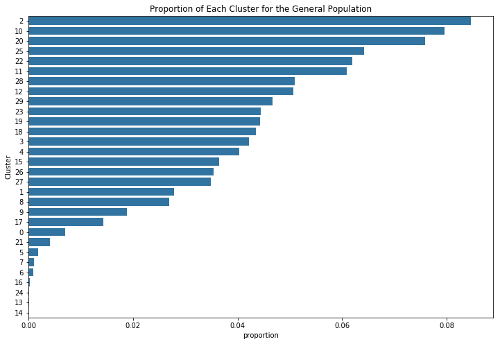

```python
fig, ax = plt.subplots(figsize=(12,8))
show_proportion(azdias_cluster, title='Proportion of Each Cluster for the General Population')
```

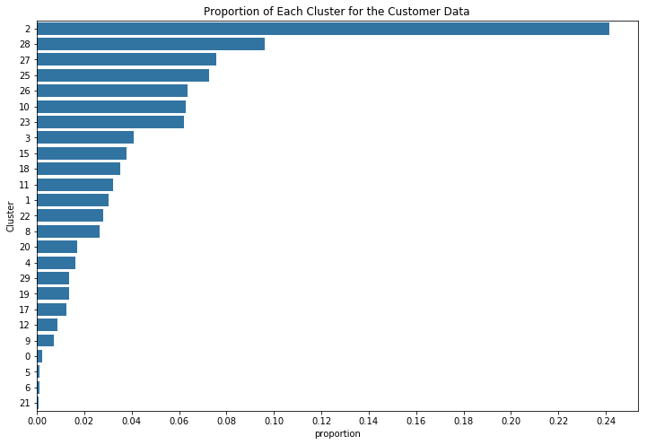

```python
fig, ax = plt.subplots(figsize=(12,8))
show_proportion(customers_cluster, title='Proportion of Each Cluster for the Customer Data')
```

```python
# Check for overrepresentation and underrepresentation of clusters between the two datasets
azdias_prop = azdias_cluster['Cluster'].value_counts() / azdias_cluster.shape[0]
customers_prop = customers_cluster['Cluster'].value_counts() / customers_cluster.shape[0]
diff_prop = customers_prop - azdias_prop

max_index = diff_prop.sort_values(ascending=False).index[0]
max_diff = diff_prop.sort_values(ascending=False).iloc[0]
min_index = diff_prop.sort_values(ascending=False).index[-6]
min_diff = diff_prop.sort_values(ascending=False).iloc[-6]
```

```python
diff_prop.sort_values(ascending=False)
```

```
2     0.156761
28    0.045264
27    0.041009
26    0.028064
23    0.017605
25    0.008587
1     0.002478
15    0.001328
6     0.000151
8    -0.000485
5    -0.000497
3    -0.001171
17   -0.001841
21   -0.003391
0    -0.004710
```

[output cut: 16 more lines]

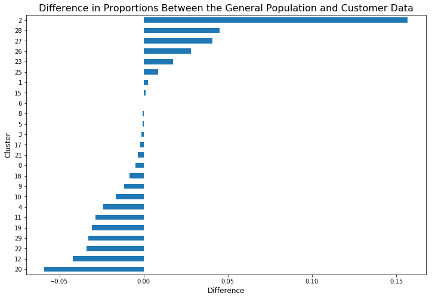

```python
fig, ax = plt.subplots(figsize=(12,8))
diff_prop.sort_values()[:25].plot.barh(color=sns.color_palette()[0])
plt.title("Difference in Proportions Between the General Population and Customer Data", fontsize=16)
plt.xlabel("Difference", fontsize=12)
plt.ylabel("Cluster", fontsize=12);
```

```python
# Function to transform centroids back to the original data space based on cluster number
def infer_cluster(index):

    # Subset the customers_cluster dataframe by the selected index
    cluster = customers_cluster[customers_cluster['Cluster'] == index]
    cluster_drop = cluster.drop('Cluster', axis=1)

    # Perform inverse PCA and inverse scaling to return to the original values
    cluster_pca = pca.inverse_transform(cluster_drop)
    cluster_scaler = scaler.inverse_transform(cluster_pca)

    # Create a new dataframe of the cluster and reuse the feature columns
    cluster_final = pd.DataFrame(cluster_scaler, columns=customers_clean.columns)
    return cluster_final
```

```python
# Columns to infer based on Step 2.3
infer_columns = ['MOBI_REGIO',
                 'PLZ8_ANTG1',
                 'KBA13_ANTG1',
                 'ONLINE_AFFINITAET',
                 'DECADE',
                 'D19_GESAMT_ANZ_24',
                 'KBA13_HERST_BMW_BENZ',
                 'KBA13_SEG_OBEREMITTELKLASSE',
                 'KBA13_MERCEDES']
```

```python
# What kinds of people are part of a cluster that is overrepresented in the
# customer data compared to the general population?
print('The cluster which is the most overrepresented is cluster {} with a difference of {}.'
         .format(max_index, np.round(max_diff, 4)))
```

```
The cluster which is the most overrepresented is cluster 2 with a difference of 0.1568.
```

```python
over_cluster = infer_cluster(max_index)
print(over_cluster.shape)
over_cluster.head()
```

```
(46249, 595)
```

|  | AKT_DAT_KL | ANZ_HAUSHALTE_AKTIV | ANZ_HH_TITEL | ANZ_KINDER | ANZ_PERSONEN | ANZ_STATISTISCHE_HAUSHALTE | ANZ_TITEL | ARBEIT | BALLRAUM | CJT_KATALOGNUTZER | ... | DECADE | MOVEMENT | WEALTH | LIFE_STAGE | ALTERSKATEGORIE_FEIN_1.0 | EINGEZOGENAM_HH_JAHR_1900.0 | EINGEZOGENAM_HH_JAHR_1904.0 | EINGEZOGENAM_HH_JAHR_1971.0 | EINGEZOGENAM_HH_JAHR_1984.0 | GEBAEUDETYP_5.0 |
| --- | --- | --- | --- | --- | --- | --- | --- | --- | --- | --- | --- | --- | --- | --- | --- | --- | --- | --- | --- | --- | --- |
| 0 | 1.735110 | 6.919821 | 0.019081 | 0.070152 | 1.903140 | 6.270570 | 0.009958 | 3.092157 | 4.074936 | 4.891862 | ... | 5.618515 | 1.177891 | 2.974710 | 3.135807 | -0.354207 | -0.465812 | -0.395109 | -0.301603 | -0.474012 | -0.107914 |
| 1 | 1.726164 | 7.041813 | 0.017183 | 0.075466 | 1.905215 | 6.381429 | 0.010618 | 3.089713 | 4.084277 | 4.947204 | ... | 5.588790 | 1.174013 | 2.968462 | 3.131828 | -0.339636 | -0.457638 | -0.380706 | -0.312271 | -0.471121 | -0.106134 |
| 2 | 1.730639 | 6.981114 | 0.018138 | 0.072800 | 1.904194 | 6.326305 | 0.010290 | 3.090951 | 4.079632 | 4.919539 | ... | 5.603601 | 1.175954 | 2.971619 | 3.133789 | -0.346977 | -0.461684 | -0.387851 | -0.306942 | -0.472580 | -0.107059 |
| 3 | 1.697736 | 7.020567 | 0.017313 | 0.077516 | 1.891668 | 6.349689 | 0.010141 | 3.092787 | 4.083699 | 5.033579 | ... | 5.526136 | 1.179572 | 2.983411 | 3.129988 | -0.348090 | -0.462231 | -0.396858 | -0.338432 | -0.488883 | -0.116923 |
| 4 | 1.688854 | 7.142743 | 0.015430 | 0.082820 | 1.893745 | 6.460701 | 0.010806 | 3.090372 | 4.093084 | 5.088941 | ... | 5.496305 | 1.175716 | 2.977173 | 3.126072 | -0.333546 | -0.454014 | -0.382467 | -0.349145 | -0.486001 | -0.115103 |

5 rows × 595 columns

```python
over_cluster[infer_columns].describe()
```

|  | MOBI_REGIO | PLZ8_ANTG1 | KBA13_ANTG1 | ONLINE_AFFINITAET | DECADE | D19_GESAMT_ANZ_24 | KBA13_HERST_BMW_BENZ | KBA13_SEG_OBEREMITTELKLASSE | KBA13_MERCEDES |
| --- | --- | --- | --- | --- | --- | --- | --- | --- | --- |
| count | 46249.000000 | 46249.000000 | 46249.000000 | 46249.000000 | 46249.000000 | 46249.000000 | 46249.000000 | 46249.000000 | 46249.000000 |
| mean | 3.310005 | 2.396009 | 2.272540 | 2.237311 | 5.668850 | 0.016421 | 3.207256 | 3.128760 | 3.172707 |
| std | 0.037502 | 0.017386 | 0.014251 | 0.154470 | 0.469711 | 0.031110 | 0.016556 | 0.021063 | 0.016640 |
| min | 2.808769 | 2.183613 | 2.138553 | 1.324002 | -0.177146 | -0.384456 | 3.119934 | 2.664873 | 2.957041 |
| 25% | 3.305156 | 2.395538 | 2.272066 | 2.240326 | 5.526136 | 0.008525 | 3.201660 | 3.127541 | 3.168566 |
| 50% | 3.315102 | 2.397615 | 2.273637 | 2.242182 | 5.588790 | 0.016176 | 3.204763 | 3.133106 | 3.169449 |
| 75% | 3.320445 | 2.399771 | 2.276291 | 2.243367 | 5.618515 | 0.017794 | 3.205679 | 3.136620 | 3.171647 |
| max | 5.011192 | 3.549090 | 3.358653 | 4.020782 | 9.373158 | 2.831033 | 3.990874 | 3.621267 | 3.831461 |

```python
# What kinds of people are part of a cluster that is underrepresented in the
# customer data compared to the general population?
print('The cluster which is the most underrepresented is cluster {} with a difference of {}.'
         .format(min_index, np.round(min_diff, 4)))
```

```
The cluster which is the most underrepresented is cluster 20 with a difference of -0.0589.
```

```python
under_cluster = infer_cluster(min_index)
print(under_cluster.shape)
under_cluster.head()
```

```
(3246, 595)
```

|  | AKT_DAT_KL | ANZ_HAUSHALTE_AKTIV | ANZ_HH_TITEL | ANZ_KINDER | ANZ_PERSONEN | ANZ_STATISTISCHE_HAUSHALTE | ANZ_TITEL | ARBEIT | BALLRAUM | CJT_KATALOGNUTZER | ... | DECADE | MOVEMENT | WEALTH | LIFE_STAGE | ALTERSKATEGORIE_FEIN_1.0 | EINGEZOGENAM_HH_JAHR_1900.0 | EINGEZOGENAM_HH_JAHR_1904.0 | EINGEZOGENAM_HH_JAHR_1971.0 | EINGEZOGENAM_HH_JAHR_1984.0 | GEBAEUDETYP_5.0 |
| --- | --- | --- | --- | --- | --- | --- | --- | --- | --- | --- | --- | --- | --- | --- | --- | --- | --- | --- | --- | --- | --- |
| 0 | 2.057415 | -0.194023 | -0.076970 | -0.101589 | 2.861343 | -0.290904 | -0.001404 | 4.327983 | 3.085619 | 4.549034 | ... | 5.281863 | 1.507397 | 2.251395 | 3.563614 | 0.015861 | -0.026517 | 0.205654 | 0.413993 | -0.599008 | 0.103716 |
| 1 | 2.910616 | 3.664950 | 0.080451 | -0.178110 | 0.963547 | 3.312384 | 0.005430 | 1.911417 | 4.447241 | 0.941672 | ... | 6.208601 | 0.716095 | 3.508911 | 2.473956 | 1.146888 | 0.928602 | 0.478097 | 0.289906 | -1.807122 | 0.022623 |
| 2 | 2.494398 | 11.031675 | -0.220579 | 0.291249 | 0.240229 | 9.773472 | -0.059429 | 3.480339 | 2.378972 | 4.152499 | ... | 6.791495 | 0.822003 | 2.725057 | 5.617520 | 0.078532 | -0.041291 | 0.189857 | 0.050902 | -0.064697 | -0.196703 |
| 3 | 5.477810 | 3.152954 | -0.041159 | -0.083787 | 1.296294 | 2.964117 | 0.009161 | 2.666368 | 6.676641 | 4.267809 | ... | 11.557251 | 1.260779 | 3.571851 | 4.647905 | 1.023266 | 0.989677 | 0.521150 | -0.007716 | -1.717468 | -0.824404 |
| 4 | 4.730982 | 17.705641 | 0.177238 | -0.079632 | 1.353592 | 16.908486 | -0.025811 | 3.086647 | 8.020412 | 3.497831 | ... | 3.339286 | 0.882932 | 2.679200 | 4.059290 | 0.036043 | -0.063627 | -0.152317 | -0.252657 | 0.544291 | 0.014749 |

5 rows × 595 columns

```python
under_cluster[infer_columns].describe()
```

|  | MOBI_REGIO | PLZ8_ANTG1 | KBA13_ANTG1 | ONLINE_AFFINITAET | DECADE | D19_GESAMT_ANZ_24 | KBA13_HERST_BMW_BENZ | KBA13_SEG_OBEREMITTELKLASSE | KBA13_MERCEDES |
| --- | --- | --- | --- | --- | --- | --- | --- | --- | --- |
| count | 3246.000000 | 3246.000000 | 3246.000000 | 3246.000000 | 3246.000000 | 3246.000000 | 3246.000000 | 3246.000000 | 3246.000000 |
| mean | 2.672904 | 2.245330 | 2.134898 | 2.594211 | 7.235118 | 0.769523 | 3.447415 | 3.262351 | 3.360993 |
| std | 0.872968 | 0.500642 | 0.464759 | 0.830011 | 2.561557 | 0.816323 | 0.611434 | 0.522745 | 0.603782 |
| min | -0.135777 | 0.363061 | 0.414129 | 0.349407 | -0.089390 | -0.568099 | 0.542501 | 0.920361 | 0.141509 |
| 25% | 1.947588 | 1.953930 | 1.867369 | 1.990617 | 5.647328 | 0.130581 | 3.121850 | 2.965997 | 3.019161 |
| 50% | 2.837635 | 2.305115 | 2.198797 | 2.553367 | 6.781580 | 0.463779 | 3.297562 | 3.197636 | 3.256846 |
| 75% | 3.323658 | 2.544484 | 2.398310 | 3.150084 | 8.519828 | 1.311193 | 3.839189 | 3.578871 | 3.714581 |
| max | 7.241359 | 3.931872 | 3.723095 | 6.490461 | 18.460215 | 4.106041 | 5.423402 | 5.174173 | 6.643829 |

```python
# Compare the differences between the target and non-target groups
over_mean = over_cluster[infer_columns].describe().loc['mean']
under_mean = under_cluster[infer_columns].describe().loc['mean']
mean_df = pd.concat([over_mean, under_mean], axis=1)
mean_df.columns = ['Target', 'Non-Target']
```

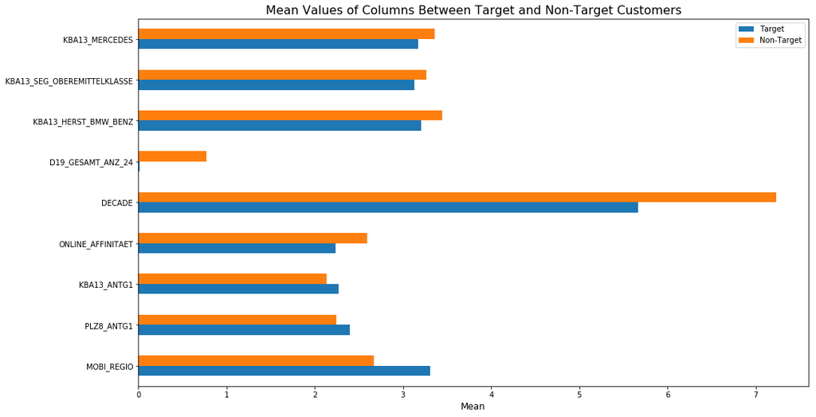

```python
# Plot the means of the columns of interests for the target and non-target groups
fig, ax = plt.subplots(figsize=(16,9))
plt.title("Mean Values of Columns Between Target and Non-Target Customers", fontsize=16)
plt.xlabel("Mean", fontsize=12)
mean_df.plot.barh(ax=ax);
```

#### Discussion 3.3 Compare Customer Data to Demographics Data

Since there are over 595 features, it will be impractical to check each feature to interpret the two clusters. Based on the principal component interpretations from step 2.3, the columns to be interpreted on the original data of the chosen clusters can be identified.

Only three out of the nine features above are clearly different. These are `D19_GESAMT_ANZ_24`, `DECADE`, and `MOBI_REGIO`. The target customers are less mobile, less recent dominating movement in their youths which probably means they are older, and have very low to none transactions in the past 24 months.

## Part 2: Supervised Learning Model

Now that you've found which parts of the population are more likely to be customers of the mail-order company, it's time to build a prediction model. Each of the rows in the "MAILOUT" data files represents an individual that was targeted for a mailout campaign. Ideally, we should be able to use the demographic information from each individual to decide whether or not it will be worth it to include that person in the campaign.

The "MAILOUT" data has been split into two approximately equal parts, each with almost 43 000 data rows. In this part, you can verify your model with the "TRAIN" partition, which includes a column, "RESPONSE", that states whether or not a person became a customer of the company following the campaign. In the next part, you'll need to create predictions on the "TEST" partition, where the "RESPONSE" column has been withheld.

### Exploring the Data

The last column `RESPONSE` will be the target label (whether or not the customer becamse a customer or not). All other applicable columns are features about each individual in the mailout campaign.

```python
#mailout_train = pd.read_csv('../../data/Term2/capstone/arvato_data/Udacity_MAILOUT_052018_TRAIN.csv', sep=';')
```

```python
mailout_train = pd.read_csv('data/mailout_train.csv', dtype=dtypes)
mailout_train.head()
```

|  | LNR | AGER_TYP | AKT_DAT_KL | ALTER_HH | ALTER_KIND1 | ALTER_KIND2 | ALTER_KIND3 | ALTER_KIND4 | ALTERSKATEGORIE_FEIN | ANZ_HAUSHALTE_AKTIV | ... | VK_DHT4A | VK_DISTANZ | VK_ZG11 | W_KEIT_KIND_HH | WOHNDAUER_2008 | WOHNLAGE | ZABEOTYP | RESPONSE | ANREDE_KZ | ALTERSKATEGORIE_GROB |
| --- | --- | --- | --- | --- | --- | --- | --- | --- | --- | --- | --- | --- | --- | --- | --- | --- | --- | --- | --- | --- | --- |
| 0 | 1763 | 2 | 1.0 | 8.0 | NaN | NaN | NaN | NaN | 8.0 | 15.0 | ... | 5.0 | 2.0 | 1.0 | 6.0 | 9.0 | 3.0 | 3 | 0 | 2 | 4 |
| 1 | 1771 | 1 | 4.0 | 13.0 | NaN | NaN | NaN | NaN | 13.0 | 1.0 | ... | 1.0 | 2.0 | 1.0 | 4.0 | 9.0 | 7.0 | 1 | 0 | 2 | 3 |
| 2 | 1776 | 1 | 1.0 | 9.0 | NaN | NaN | NaN | NaN | 7.0 | 0.0 | ... | 6.0 | 4.0 | 2.0 | NaN | 9.0 | 2.0 | 3 | 0 | 1 | 4 |
| 3 | 1460 | 2 | 1.0 | 6.0 | NaN | NaN | NaN | NaN | 6.0 | 4.0 | ... | 8.0 | 11.0 | 11.0 | 6.0 | 9.0 | 1.0 | 3 | 0 | 2 | 4 |
| 4 | 1783 | 2 | 1.0 | 9.0 | NaN | NaN | NaN | NaN | 9.0 | 53.0 | ... | 2.0 | 2.0 | 1.0 | 6.0 | 9.0 | 3.0 | 3 | 0 | 1 | 3 |

5 rows × 367 columns

```python
# Total number of records
n_records = mailout_train.shape[0]

# Number of records where the individual became a customer
n_customer = mailout_train[mailout_train['RESPONSE'] == 1].shape[0]

# Number of records where individual did not become a customer
n_not_customer = mailout_train[mailout_train['RESPONSE'] == 0].shape[0]

# Percentage of individuals who became customers
customer_perc = (n_customer / n_records) * 100

# Print the results
print("Total number of records: {}".format(n_records))
print("Individuals who became customers: {}".format(n_customer))
print("Individuals who did not become customers: {}".format(n_not_customer))
print("Percentage of individuals who became customers: {}%".format(customer_perc))
```

```
Total number of records: 42962
Individuals who became customers: 532
Individuals who did not become customers: 42430
Percentage of individuals who became customers: 1.2383036171500394%
```

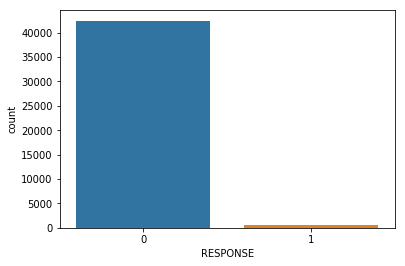

```python
sns.countplot("RESPONSE",data=mailout_train)
```

Out of all the 42,962 individuals in the mailout campaign, only 1.24% of the individuals became customers. The dataset is highly imbalanced because of the disproportionate amount of customers and non-customers.

### Preparing the Data

Before the imbalanced dataset can be used as input for machine learning algorithms, it often must be cleaned, formatted, and restructured — this is typically known as preprocessing. Fortunately, the features are similar to the general population dataset and the customers dataset.

```python
# Prepare the data using the function created earlier
mailout_train_clean = clean_data(mailout_train)
```

```python
print(mailout_train_clean.shape)
mailout_train_clean.head()
```

```
(42962, 590)
```

|  | AKT_DAT_KL | ANZ_HAUSHALTE_AKTIV | ANZ_HH_TITEL | ANZ_KINDER | ANZ_PERSONEN | ANZ_STATISTISCHE_HAUSHALTE | ANZ_TITEL | ARBEIT | BALLRAUM | CJT_KATALOGNUTZER | ... | WOHNLAGE_2.0 | WOHNLAGE_3.0 | WOHNLAGE_4.0 | WOHNLAGE_5.0 | WOHNLAGE_7.0 | WOHNLAGE_8.0 | DECADE | MOVEMENT | WEALTH | LIFE_STAGE |
| --- | --- | --- | --- | --- | --- | --- | --- | --- | --- | --- | --- | --- | --- | --- | --- | --- | --- | --- | --- | --- | --- |
| 0 | 1.0 | 15.0 | 0.0 | 0.0 | 1.0 | 13.0 | 0.0 | 3.0 | 5.0 | 5.0 | ... | 0 | 1 | 0 | 0 | 0 | 0 | 1.0 | 1.0 | 3.0 | 4.0 |
| 1 | 4.0 | 1.0 | 0.0 | 0.0 | 2.0 | 1.0 | 0.0 | 2.0 | 5.0 | 2.0 | ... | 0 | 0 | 0 | 0 | 1 | 0 | 8.0 | 1.0 | 3.0 | 2.0 |
| 2 | 1.0 | NaN | NaN | 0.0 | 0.0 | 1.0 | 0.0 | 4.0 | 1.0 | 5.0 | ... | 1 | 0 | 0 | 0 | 0 | 0 | 2.0 | 2.0 | 1.0 | 4.0 |
| 3 | 1.0 | 4.0 | 0.0 | 0.0 | 2.0 | 4.0 | 0.0 | 4.0 | 2.0 | 5.0 | ... | 0 | 0 | 0 | 0 | 0 | 0 | 2.0 | 2.0 | 1.0 | 4.0 |
| 4 | 1.0 | 53.0 | 0.0 | 0.0 | 1.0 | 44.0 | 0.0 | 3.0 | 4.0 | 5.0 | ... | 0 | 1 | 0 | 0 | 0 | 0 | 3.0 | 1.0 | 4.0 | 1.0 |

5 rows × 590 columns

```python
# Check for missing column in `clean_mailout_train`
missing = list(np.setdiff1d(customers_clean.columns, mailout_train_clean.columns))
missing
```

```
['ALTERSKATEGORIE_FEIN_1.0',
 'EINGEZOGENAM_HH_JAHR_1900.0',
 'EINGEZOGENAM_HH_JAHR_1904.0',
 'EINGEZOGENAM_HH_JAHR_1971.0',
 'EINGEZOGENAM_HH_JAHR_1984.0',
 'GEBAEUDETYP_5.0']
```

```python
# Add the missing column with default value of 0
for m in missing:
    mailout_train_clean[m] = 0
    mailout_train_clean[m] = mailout_train_clean[m].astype('uint8')
mailout_train_clean.info()
```

```
<class 'pandas.core.frame.DataFrame'>
RangeIndex: 42962 entries, 0 to 42961
Columns: 596 entries, AKT_DAT_KL to GEBAEUDETYP_5.0
dtypes: float64(332), int64(1), uint8(263)
memory usage: 119.9 MB
```

```python
# Split the data into features and target label
response_raw = mailout_train_clean['RESPONSE']
features_raw = mailout_train_clean.drop('RESPONSE', axis = 1)
```

### Shuffle and Split the Data

Now, the dataset has been preprocessed and is now ready for machine learning. As always, we will now split the data (both features and their labels) into training and test sets. Due to class imbalance, a variation of KFold that returns stratified folds will be implemented. The folds made will preserve the percentage of samples for each class.

```python
# Import StratifiedKFold
from sklearn.model_selection import StratifiedKFold

# Initialize 5 stratified folds
skf = StratifiedKFold(n_splits=5, random_state=28)
skf.get_n_splits(features_raw, response_raw)
print(skf)
```

```
StratifiedKFold(n_splits=5, random_state=28, shuffle=False)
```

### Evaluating Model Performance

Since there is a large output class imbalance, predicting individual classes and using accuracy does not seem to be an appropriate performance evaluation method. Instead, the model will be using ROC-AUC to evaluate performance.

Aside from the Kaggle competition (see section below) using ROC-AUC as the score, the metric is suitable for binary classification problems such as this. Jason Brownlee, in his [article](https://machinelearningmastery.com/assessing-comparing-classifier-performance-roc-curves-2/) explains that "ROC curves give us the ability to assess the performance of the classifier over its entire operating range. The most widely-used measure is the area under the curve (AUC). The AUC can be used to compare the performance of two or more classifiers. A single threshold can be selected and the classifiers’ performance at that point compared, or the overall performance can be compared by considering the AUC". Compared to the F1 score, the ROC does not require optimizing a threshold for each label.

There are a number of approaches to deal with class imbalance which have been already explained by numerous blog posts from different experts. This particular [article](https://www.analyticsvidhya.com/blog/2017/03/imbalanced-classification-problem/) from Analytics Vidhya describes the following techniques:

1. Random Over-sampling
2. Random Under-sampling
3. Cluster-Based Over-sampling
4. Informed Over Sampling: Synthetic Minority Over-sampling Technique (SMOTE)
5. Modified synthetic minority oversampling technique (MSMOTE)

The above approaches deals with handling imbalanced data by resampling original data to provide balanced classes. The same article also provides an alternative approach of modifying existing classification algorithms to make them appropriate for imbalanced data sets.

1. Bagging-Based
2. Boosting-Based
3. Adaptive Boosting
4. Gradient Tree Boosting
5. Extreme Gradient Boosting

The last three algorithms will be investigated to determine which is best at modeling the data.

```python
# Import libraries for machine learning pipeline
from sklearn.ensemble import AdaBoostRegressor # Adaptive Boosting
from sklearn.ensemble import GradientBoostingRegressor # Gradient Tree Boosting
from xgboost.sklearn import XGBRegressor # Extreme Gradient Boosting

clf_A = AdaBoostRegressor(random_state=28)
clf_B = GradientBoostingRegressor(random_state=28)
clf_C = XGBRegressor(random_state=28)
```

```python
model_scores = {}

for i, clf in enumerate([clf_A, clf_B, clf_C]):

    # Create machine learning pipeline
    pipeline = Pipeline([
        ('imp', imputer),
        ('scale', scaler),
        ('clf', clf)
    ])

    scores = []
    j = 0

    # Perform 5-fold validation
    for train_index, test_index in skf.split(features_raw, response_raw):
        j+=1
        print('Classifier {}: Fold {}...'.format(i+1, j))

        # Split the data into training and test sets
        X_train, X_test = features_raw.iloc[train_index], features_raw.iloc[test_index]
        y_train, y_test = response_raw.iloc[train_index], response_raw.iloc[test_index]

        # Train using the pipeline
        pipeline.fit(X_train, y_train)

        #Predict on the test data
        y_pred = pipeline.predict(X_test)

        score = roc_auc_score(y_test, y_pred)
        scores.append(score)
        print(score)

    model_scores[clf] = scores
```

```
Classifier 1: Fold 1...
0.7380446298576434
Classifier 1: Fold 2...
0.7431123499727974
Classifier 1: Fold 3...
0.7810733772384261
Classifier 1: Fold 4...
0.7407411318975983
Classifier 1: Fold 5...
0.7555196350037131
Classifier 2: Fold 1...
0.7179345419944009
Classifier 2: Fold 2...
0.7450793059927181
Classifier 2: Fold 3...
0.7979591246848305
Classifier 2: Fold 4...
0.7347890421070887
Classifier 2: Fold 5...
0.7707606090386386
Classifier 3: Fold 1...
0.7182952240193303
Classifier 3: Fold 2...
0.7477593661687969
Classifier 3: Fold 3...
0.790357814646988
Classifier 3: Fold 4...
0.7390652306351415
Classifier 3: Fold 5...
0.771342588681024
```

```python
scores_df = pd.DataFrame(model_scores)
scores_df.columns = ['AdaBoostRegressor', 'GradientBoostingRegressor', 'XGBRegressor']
scores_df
```

|  | AdaBoostRegressor | GradientBoostingRegressor | XGBRegressor |
| --- | --- | --- | --- |
| 0 | 0.738045 | 0.717935 | 0.718295 |
| 1 | 0.743112 | 0.745079 | 0.747759 |
| 2 | 0.781073 | 0.797959 | 0.790358 |
| 3 | 0.740741 | 0.734789 | 0.739065 |
| 4 | 0.755520 | 0.770761 | 0.771343 |

```python
scores_df.describe()
```

|  | AdaBoostRegressor | GradientBoostingRegressor | XGBRegressor |
| --- | --- | --- | --- |
| count | 5.000000 | 5.000000 | 5.000000 |
| mean | 0.751698 | 0.753305 | 0.753364 |
| std | 0.017732 | 0.031465 | 0.028096 |
| min | 0.738045 | 0.717935 | 0.718295 |
| 25% | 0.740741 | 0.734789 | 0.739065 |
| 50% | 0.743112 | 0.745079 | 0.747759 |
| 75% | 0.755520 | 0.770761 | 0.771343 |
| max | 0.781073 | 0.797959 | 0.790358 |

### Improving Results

Among the three models namely `AdaBoostRegressor`, `GradientBoostingRegressor`, and `XGBRegressor`, the last one performed best based on the mean score. It beat out the other two models by a small margin. Actually, Extreme Gradient Boosting is an advanced and more efficient implementation of Gradient Boosting so it makes sense that it should have the highest score.

Another [article](https://www.analyticsvidhya.com/blog/2016/03/complete-guide-parameter-tuning-xgboost-with-codes-python/) from Analytics Vidhya lists the advantages of XGBoost:

1. Regularization
2. Parallel Processing
3. High Flexibility
4. Handling Missing Values
5. Tree Pruning
6. Built-in Cross Validation
7. Continue on Existing Model

```python
# Create function to make a machine learning pipeline

def create_pipeline(clf):

    # Create machine learning pipeline
    pipeline = Pipeline([
        ('imp', imputer),
        ('scale', scaler),
        ('clf', clf)
    ])

    return pipeline
```

```python
# Create function to do 5-fold cross-validation above

def cross_validate(clf):

    pipeline = create_pipeline(clf)
    scores = []
    i = 0

    # Perform 5-fold validation
    for train_index, test_index in skf.split(features_raw, response_raw):
        i+=1
        print('Fold {}'.format(i))

        # Split the data into training and test sets
        X_train, X_test = features_raw.iloc[train_index], features_raw.iloc[test_index]
        y_train, y_test = response_raw.iloc[train_index], response_raw.iloc[test_index]

        # Train using the pipeline
        pipeline.fit(X_train, y_train)

        #Predict on the test data
        y_pred = pipeline.predict(X_test)

        score = roc_auc_score(y_test, y_pred)
        scores.append(score)
        print("Score: {}".format(score))

    return scores
```

```python
# Create initial model
clf_0 = XGBRegressor(
    objective = 'binary:logistic', #logistic regression for binary classification
    scale_pos_weight = 1, #because of high class imbalance
    random_state = 28)
```

```python
tuned_scores0 = cross_validate(clf_0)
```

```
Fold 1
Score: 0.7189295838555422
Fold 2
Score: 0.7462472549619934
Fold 3
Score: 0.7972370697130456
Fold 4
Score: 0.749885493976761
Fold 5
Score: 0.7533957150289712
```

```python
np.array(tuned_scores0).mean()
```

```
0.7531390235072626
```

#### Tune `max_depth` and `min_child_weight`

These will be tuned first because they have the highest impact on the model outcome.

```python
pipeline = Pipeline([
        ('imp', imputer),
        ('scale', scaler),
        ('clf', clf_0)
])

parameters_1 = {
    'clf__max_depth': range(3,10,2),
    'clf__min_child_weight': range(1,6,2)
}

cv = GridSearchCV(estimator=pipeline, param_grid=parameters_1, scoring='roc_auc',n_jobs=-1, iid=False, cv=5)
cv.fit(features_raw, response_raw)
cv.grid_scores_, cv.best_params_, cv.best_score_
```

```
([mean: 0.75193, std: 0.02334, params: {'clf__max_depth': 3, 'clf__min_child_weight': 1},
  mean: 0.75230, std: 0.02272, params: {'clf__max_depth': 3, 'clf__min_child_weight': 3},
  mean: 0.75597, std: 0.01813, params: {'clf__max_depth': 3, 'clf__min_child_weight': 5},
  mean: 0.74874, std: 0.02374, params: {'clf__max_depth': 5, 'clf__min_child_weight': 1},
  mean: 0.74494, std: 0.02448, params: {'clf__max_depth': 5, 'clf__min_child_weight': 3},
  mean: 0.74872, std: 0.01665, params: {'clf__max_depth': 5, 'clf__min_child_weight': 5},
  mean: 0.73206, std: 0.02376, params: {'clf__max_depth': 7, 'clf__min_child_weight': 1},
  mean: 0.73952, std: 0.02296, params: {'clf__max_depth': 7, 'clf__min_child_weight': 3},
  mean: 0.74038, std: 0.02050, params: {'clf__max_depth': 7, 'clf__min_child_weight': 5},
  mean: 0.72107, std: 0.02611, params: {'clf__max_depth': 9, 'clf__min_child_weight': 1},
  mean: 0.72296, std: 0.01847, params: {'clf__max_depth': 9, 'clf__min_child_weight': 3},
  mean: 0.73113, std: 0.01527, params: {'clf__max_depth': 9, 'clf__min_child_weight': 5}],
 {'clf__max_depth': 3, 'clf__min_child_weight': 5},
 0.7559679124177826)
```

```python
# Update model
clf_1 = XGBRegressor(
    max_depth = 3,
    min_child_weight = 5,
    objective = 'binary:logistic',
    scale_pos_weight = 1,
    random_state = 28)
```

```python
tuned_scores1 = cross_validate(clf_1)
```

```
Fold 1
Score: 0.7308431038698153
Fold 2
Score: 0.7432290898037669
Fold 3
Score: 0.7922110334891207
Fold 4
Score: 0.7502573606250473
Fold 5
Score: 0.7544501709808387
```

```python
np.array(tuned_scores1).mean()
```

```
0.7541981517537177
```

#### Tune `gamma`

```python
pipeline = Pipeline([
        ('imp', imputer),
        ('scale', scaler),
        ('clf', clf_1)
])

parameters_2 = {
    'clf__gamma': [i/10.0 for i in range(0,5)]
}

cv = GridSearchCV(estimator=pipeline, param_grid=parameters_2, scoring='roc_auc',n_jobs=-1, iid=False, cv=5)
cv.fit(features_raw, response_raw)
cv.grid_scores_, cv.best_params_, cv.best_score_
```

```
([mean: 0.75597, std: 0.01813, params: {'clf__gamma': 0.0},
  mean: 0.75549, std: 0.01910, params: {'clf__gamma': 0.1},
  mean: 0.75667, std: 0.02068, params: {'clf__gamma': 0.2},
  mean: 0.75494, std: 0.02265, params: {'clf__gamma': 0.3},
  mean: 0.75574, std: 0.02040, params: {'clf__gamma': 0.4}],
 {'clf__gamma': 0.2},
 0.7566672240482213)
```

```python
clf_2 = XGBRegressor(
    gamma = 0.2,
    max_depth = 3,
    min_child_weight = 1,
    objective = 'binary:logistic',
    scale_pos_weight = 1,
    random_state = 28)
```

```python
tuned_scores2 = cross_validate(clf_1)
```

```
Fold 1
Score: 0.7308431038698153
Fold 2
Score: 0.7432290898037669
Fold 3
Score: 0.7922110334891207
Fold 4
Score: 0.7502573606250473
Fold 5
Score: 0.7544501709808387
```

```python
np.array(tuned_scores2).mean()
```

```
0.7541981517537177
```

#### Tune `subsample` and `colsample_bytree`

```python
pipeline = Pipeline([
        ('imp', imputer),
        ('scale', scaler),
        ('clf', clf_2)
])

parameters_3 = {
    'clf__subsample':[i/10.0 for i in range(6,10)],
    'clf__colsample_bytree':[i/10.0 for i in range(6,10)]
}

cv = GridSearchCV(estimator=pipeline, param_grid=parameters_3, scoring='roc_auc',n_jobs=-1, iid=False, cv=5)
cv.fit(features_raw, response_raw)
cv.grid_scores_, cv.best_params_, cv.best_score_
```

```
([mean: 0.76329, std: 0.01886, params: {'clf__colsample_bytree': 0.6, 'clf__subsample': 0.6},
  mean: 0.76462, std: 0.02203, params: {'clf__colsample_bytree': 0.6, 'clf__subsample': 0.7},
  mean: 0.75798, std: 0.02249, params: {'clf__colsample_bytree': 0.6, 'clf__subsample': 0.8},
  mean: 0.75763, std: 0.02154, params: {'clf__colsample_bytree': 0.6, 'clf__subsample': 0.9},
  mean: 0.76502, std: 0.01883, params: {'clf__colsample_bytree': 0.7, 'clf__subsample': 0.6},
  mean: 0.75869, std: 0.01839, params: {'clf__colsample_bytree': 0.7, 'clf__subsample': 0.7},
  mean: 0.76136, std: 0.02469, params: {'clf__colsample_bytree': 0.7, 'clf__subsample': 0.8},
  mean: 0.75812, std: 0.01661, params: {'clf__colsample_bytree': 0.7, 'clf__subsample': 0.9},
  mean: 0.76491, std: 0.01668, params: {'clf__colsample_bytree': 0.8, 'clf__subsample': 0.6},
  mean: 0.75855, std: 0.02138, params: {'clf__colsample_bytree': 0.8, 'clf__subsample': 0.7},
  mean: 0.76090, std: 0.02188, params: {'clf__colsample_bytree': 0.8, 'clf__subsample': 0.8},
  mean: 0.75824, std: 0.02461, params: {'clf__colsample_bytree': 0.8, 'clf__subsample': 0.9},
  mean: 0.76225, std: 0.01780, params: {'clf__colsample_bytree': 0.9, 'clf__subsample': 0.6},
  mean: 0.75905, std: 0.02294, params: {'clf__colsample_bytree': 0.9, 'clf__subsample': 0.7},
  mean: 0.76311, std: 0.02206, params: {'clf__colsample_bytree': 0.9, 'clf__subsample': 0.8},
  mean: 0.75316, std: 0.02074, params: {'clf__colsample_bytree': 0.9, 'clf__subsample': 0.9}],
 {'clf__colsample_bytree': 0.7, 'clf__subsample': 0.6},
 0.7650217766140122)
```

```python
clf_3 = XGBRegressor(
    subsample = 0.6,
    colsample_bytree = 0.7,
    gamma = 0.2,
    max_depth = 3,
    min_child_weight = 1,
    objective = 'binary:logistic',
    scale_pos_weight = 1,
    random_state = 28)
```

```python
tuned_scores3 = cross_validate(clf_3)
```

```
Fold 1
Score: 0.7452533144200123
Fold 2
Score: 0.7633964462633341
Fold 3
Score: 0.8116753898763335
Fold 4
Score: 0.7526403087882817
Fold 5
Score: 0.765751248449166
```

```python
np.array(tuned_scores3).mean()
```

```
0.7677433415594255
```

#### Tuning Regularization Parameters

```python
pipeline = Pipeline([
        ('imp', imputer),
        ('scale', scaler),
        ('clf', clf_3)
])

parameters_4 = {
    'clf__reg_alpha':[1e-5, 1e-2, 0.1, 1, 100]
}

cv = GridSearchCV(estimator=pipeline, param_grid=parameters_4, scoring='roc_auc',n_jobs=-1, iid=False, cv=5)
cv.fit(features_raw, response_raw)
cv.grid_scores_, cv.best_params_, cv.best_score_
```

```
([mean: 0.76502, std: 0.01883, params: {'clf__reg_alpha': 1e-05},
  mean: 0.76426, std: 0.02027, params: {'clf__reg_alpha': 0.01},
  mean: 0.76532, std: 0.01975, params: {'clf__reg_alpha': 0.1},
  mean: 0.76361, std: 0.02237, params: {'clf__reg_alpha': 1},
  mean: 0.63877, std: 0.03316, params: {'clf__reg_alpha': 100}],
 {'clf__reg_alpha': 0.1},
 0.7653152660483415)
```

```python
clf_4 = XGBRegressor(
    reg_alpha = 0.1,
    subsample = 0.6,
    colsample_bytree = 0.7,
    gamma = 0.2,
    max_depth = 3,
    min_child_weight = 1,
    objective = 'binary:logistic',
    scale_pos_weight = 1,
    random_state = 28)
```

```python
tuned_scores4 = cross_validate(clf_4)
```

```
Fold 1
Score: 0.74412336096176
Fold 2
Score: 0.7662317924409858
Fold 3
Score: 0.8062836014034214
Fold 4
Score: 0.7542556219122285
Fold 5
Score: 0.7645328154251841
```

```python
np.array(tuned_scores4).mean()
```

```
0.767085438428716
```

```python
pipeline = Pipeline([
        ('imp', imputer),
        ('scale', scaler),
        ('clf', clf_4)
])

parameters_5 = {
    'clf__reg_alpha':[0, 0.001, 0.005, 0.01, 0.05]
}

cv = GridSearchCV(estimator=pipeline, param_grid=parameters_5, scoring='roc_auc',n_jobs=-1, iid=False, cv=5)
cv.fit(features_raw, response_raw)
cv.grid_scores_, cv.best_params_, cv.best_score_
```

```
([mean: 0.76502, std: 0.01883, params: {'clf__reg_alpha': 0},
  mean: 0.76463, std: 0.01876, params: {'clf__reg_alpha': 0.001},
  mean: 0.76366, std: 0.01984, params: {'clf__reg_alpha': 0.005},
  mean: 0.76426, std: 0.02027, params: {'clf__reg_alpha': 0.01},
  mean: 0.76669, std: 0.01869, params: {'clf__reg_alpha': 0.05}],
 {'clf__reg_alpha': 0.05},
 0.7666866784636424)
```

```python
clf_5 = XGBRegressor(
    reg_alpha = 0.05,
    subsample = 0.6,
    colsample_bytree = 0.7,
    gamma = 0.2,
    max_depth = 3,
    min_child_weight = 1,
    objective = 'binary:logistic',
    scale_pos_weight = 1,
    random_state = 28)
```

```python
tuned_scores5 = cross_validate(clf_5)
```

```
Fold 1
Score: 0.7440958279827578
Fold 2
Score: 0.7631800370483764
Fold 3
Score: 0.8103018734519453
Fold 4
Score: 0.7514552270332044
Fold 5
Score: 0.7684649300290378
```

```python
np.array(tuned_scores5).mean()
```

```
0.7674995791090643
```

#### Reduce `learning_rate` and increase `n_estimators`

```python
clf_final = XGBRegressor(
    learning_rate = 0.01,
    n_estimators = 1000,
    reg_alpha = 0.05,
    subsample = 0.6,
    colsample_bytree = 0.7,
    gamma = 0.2,
    max_depth = 3,
    min_child_weight = 1,
    objective = 'binary:logistic',
    scale_pos_weight = 1,
    random_state = 28)
```

```python
final_scores = cross_validate(clf_final)
```

```
Fold 1
Score: 0.7449311785656859
Fold 2
Score: 0.7593848912227066
Fold 3
Score: 0.8086771108018089
Fold 4
Score: 0.7560888299930185
Fold 5
Score: 0.7738378194495708
```

```python
np.array(final_scores).mean()
```

```
0.7685839660065581
```

### Check Most Important Features

```python
def feature_plot(importances, X_train, y_train, num_feat=5):

    # Display the five most important features
    indices = np.argsort(importances)[::-1]
    columns = X_train.columns.values[indices[:num_feat]]
    values = importances[indices][:num_feat]

    # Create the plot
    fig = plt.figure(figsize = (16,9))
    plt.title("Normalized Weights for the Most Predictive Features", fontsize = 16)
    plt.barh(np.arange(num_feat), values[::-1], height = 0.6, align="center", \
          label = "Feature Weight")
    plt.barh(np.arange(num_feat) - 0.3, np.cumsum(values)[::-1], height = 0.2, align = "center", \
          label = "Cumulative Feature Weight")
    plt.yticks(np.arange(num_feat), columns[::-1])
    plt.xlabel("Weight", fontsize = 12)
    plt.ylabel('')

    plt.legend(loc = 'upper right')
    plt.tight_layout()
    plt.show()
```

```python
importances = clf_5.feature_importances_
```

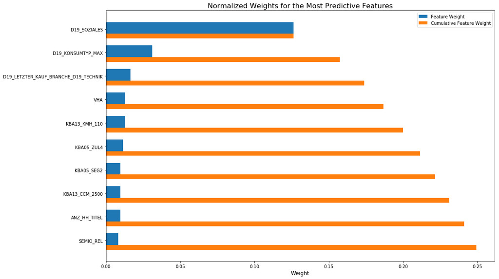

```python
feature_plot(importances, features_raw, response_raw, 10)
```

```python
over_cluster['D19_SOZIALES'].describe(), under_cluster['D19_SOZIALES'].describe()
```

```
(count    46249.000000
 mean         1.678302
 std          0.077924
 min         -1.049138
 25%          1.659921
 50%          1.668777
 75%          1.678519
 max          3.374188
 Name: D19_SOZIALES, dtype: float64, count    3246.000000
 mean        1.140023
 std         1.146373
 min        -2.371676
 25%         0.330717
 50%         1.023059
 75%         1.799786
 max         6.043304
 Name: D19_SOZIALES, dtype: float64)
```

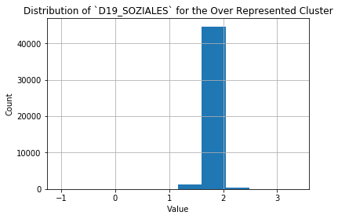

```python
over_cluster['D19_SOZIALES'].hist()
plt.xlabel('Value')
plt.ylabel('Count')
plt.title('Distribution of `D19_SOZIALES` for the Over Represented Cluster');
```

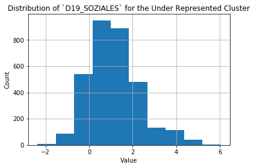

```python
under_cluster['D19_SOZIALES'].hist()
plt.xlabel('Value')
plt.ylabel('Count')
plt.title('Distribution of `D19_SOZIALES` for the Under Represented Cluster');
```

## Part 3: Kaggle Competition

Now that you've created a model to predict which individuals are most likely to respond to a mailout campaign, it's time to test that model in competition through Kaggle. If you click on the link [here](http://www.kaggle.com/t/21e6d45d4c574c7fa2d868f0e8c83140), you'll be taken to the competition page where, if you have a Kaggle account, you can enter. If you're one of the top performers, you may have the chance to be contacted by a hiring manager from Arvato or Bertelsmann for an interview!

Your entry to the competition should be a CSV file with two columns. The first column should be a copy of "LNR", which acts as an ID number for each individual in the "TEST" partition. The second column, "RESPONSE", should be some measure of how likely each individual became a customer – this might not be a straightforward probability. As you should have found in Part 2, there is a large output class imbalance, where most individuals did not respond to the mailout. Thus, predicting individual classes and using accuracy does not seem to be an appropriate performance evaluation method. Instead, the competition will be using AUC to evaluate performance. The exact values of the "RESPONSE" column do not matter as much: only that the higher values try to capture as many of the actual customers as possible, early in the ROC curve sweep.

```python
#mailout_test = pd.read_csv('../../data/Term2/capstone/arvato_data/Udacity_MAILOUT_052018_TEST.csv', sep=';')
mailout_test = pd.read_csv('data/mailout_test.csv')
```

```python
print(mailout_test.shape)
mailout_test.head()
```

```
(42833, 366)
```

|  | LNR | AGER_TYP | AKT_DAT_KL | ALTER_HH | ALTER_KIND1 | ALTER_KIND2 | ALTER_KIND3 | ALTER_KIND4 | ALTERSKATEGORIE_FEIN | ANZ_HAUSHALTE_AKTIV | ... | VHN | VK_DHT4A | VK_DISTANZ | VK_ZG11 | W_KEIT_KIND_HH | WOHNDAUER_2008 | WOHNLAGE | ZABEOTYP | ANREDE_KZ | ALTERSKATEGORIE_GROB |
| --- | --- | --- | --- | --- | --- | --- | --- | --- | --- | --- | --- | --- | --- | --- | --- | --- | --- | --- | --- | --- | --- |
| 0 | 1754 | 2 | 1.0 | 7.0 | NaN | NaN | NaN | NaN | 6.0 | 2.0 | ... | 4.0 | 5.0 | 6.0 | 3.0 | 6.0 | 9.0 | 3.0 | 3 | 1 | 4 |
| 1 | 1770 | -1 | 1.0 | 0.0 | NaN | NaN | NaN | NaN | 0.0 | 20.0 | ... | 1.0 | 5.0 | 2.0 | 1.0 | 6.0 | 9.0 | 5.0 | 3 | 1 | 4 |
| 2 | 1465 | 2 | 9.0 | 16.0 | NaN | NaN | NaN | NaN | 11.0 | 2.0 | ... | 3.0 | 9.0 | 6.0 | 3.0 | 2.0 | 9.0 | 4.0 | 3 | 2 | 4 |
| 3 | 1470 | -1 | 7.0 | 0.0 | NaN | NaN | NaN | NaN | 0.0 | 1.0 | ... | 2.0 | 6.0 | 6.0 | 3.0 | NaN | 9.0 | 2.0 | 3 | 2 | 4 |
| 4 | 1478 | 1 | 1.0 | 21.0 | NaN | NaN | NaN | NaN | 13.0 | 1.0 | ... | 1.0 | 2.0 | 4.0 | 3.0 | 3.0 | 9.0 | 7.0 | 4 | 2 | 4 |

5 rows × 366 columns

```python
mailout_test_clean = clean_data(mailout_test)
```

```python
print(mailout_test_clean.shape)
mailout_test_clean.head()
```

```
(42833, 588)
```

|  | AKT_DAT_KL | ANZ_HAUSHALTE_AKTIV | ANZ_HH_TITEL | ANZ_KINDER | ANZ_PERSONEN | ANZ_STATISTISCHE_HAUSHALTE | ANZ_TITEL | ARBEIT | BALLRAUM | CJT_KATALOGNUTZER | ... | WOHNLAGE_2.0 | WOHNLAGE_3.0 | WOHNLAGE_4.0 | WOHNLAGE_5.0 | WOHNLAGE_7.0 | WOHNLAGE_8.0 | DECADE | MOVEMENT | WEALTH | LIFE_STAGE |
| --- | --- | --- | --- | --- | --- | --- | --- | --- | --- | --- | --- | --- | --- | --- | --- | --- | --- | --- | --- | --- | --- |
| 0 | 1.0 | 2.0 | 0.0 | 0.0 | 2.0 | 2.0 | 0.0 | 3.0 | 6.0 | 5.0 | ... | 0 | 1 | 0 | 0 | 0 | 0 | 2.0 | 2.0 | 1.0 | 3.0 |
| 1 | 1.0 | 20.0 | 0.0 | 0.0 | 1.0 | 21.0 | 0.0 | 4.0 | 7.0 | 5.0 | ... | 0 | 0 | 0 | 1 | 0 | 0 | 5.0 | 1.0 | 3.0 | 1.0 |
| 2 | 9.0 | 2.0 | 0.0 | 0.0 | 4.0 | 2.0 | 0.0 | 4.0 | 1.0 | 5.0 | ... | 0 | 0 | 1 | 0 | 0 | 0 | 6.0 | 2.0 | 4.0 | 1.0 |
| 3 | 7.0 | 1.0 | 0.0 | 0.0 | 0.0 | 1.0 | 0.0 | 4.0 | 1.0 | 5.0 | ... | 1 | 0 | 0 | 0 | 0 | 0 | 5.0 | 1.0 | 1.0 | 3.0 |
| 4 | 1.0 | 1.0 | 0.0 | 0.0 | 4.0 | 1.0 | 0.0 | 3.0 | 6.0 | 1.0 | ... | 0 | 0 | 0 | 0 | 1 | 0 | 8.0 | 1.0 | 3.0 | 1.0 |

5 rows × 588 columns

```python
# Check for missing column in `clean_mailout_test`
missing = list(np.setdiff1d(customers_clean.columns, mailout_test_clean.columns))
missing
```

```
['ALTERSKATEGORIE_FEIN_1.0',
 'EINGEZOGENAM_HH_JAHR_1900.0',
 'EINGEZOGENAM_HH_JAHR_1904.0',
 'EINGEZOGENAM_HH_JAHR_1971.0',
 'EINGEZOGENAM_HH_JAHR_1984.0',
 'EINGEZOGENAM_HH_JAHR_1986.0',
 'GEBAEUDETYP_5.0']
```

```python
# Add the missing column with default value of 0
for m in missing:
    mailout_test_clean[m] = 0
    mailout_test_clean[m] = mailout_test_clean[m].astype('uint8')
mailout_test_clean.info()
```

```
<class 'pandas.core.frame.DataFrame'>
RangeIndex: 42833 entries, 0 to 42832
Columns: 595 entries, AKT_DAT_KL to GEBAEUDETYP_5.0
dtypes: float64(332), uint8(263)
memory usage: 119.2 MB
```

```python
pipeline = create_pipeline(clf_final)
pipeline.fit(features_raw, response_raw)
```

```
Pipeline(memory=None,
     steps=[('imp', Imputer(axis=0, copy=True, missing_values='NaN', strategy='mean', verbose=0)), ('scale', StandardScaler(copy=True, with_mean=True, with_std=True)), ('clf', XGBRegressor(base_score=0.5, booster='gbtree', colsample_bylevel=1,
       colsample_bytree=0.7, gamma=0.2, learning_rate=0.01,
 ...alpha=0.05,
       reg_lambda=1, scale_pos_weight=1, seed=None, silent=True,
       subsample=0.6))])
```

```python
#Predict on the test data
predictions = pipeline.predict(mailout_test_clean)
```

#### Submission

```python
submission = pd.DataFrame(index=mailout_test['LNR'].astype('int32'), data=predictions)
```

```python
submission.rename(columns={0: "RESPONSE"}, inplace=True)
submission.head()
```

| LNR | RESPONSE |
| --- | --- |
| 1754 | 0.033998 |
| 1770 | 0.035560 |
| 1465 | 0.004447 |
| 1470 | 0.005537 |
| 1478 | 0.005847 |

```python
submission.to_csv('submission.csv')
```